# Sama Amr Habib - Use Case(Loan Defaulter)

# Decision Tree Model with Balanced Data (SMOTE)

```python
from sklearn.tree import DecisionTreeClassifier
from sklearn.metrics import classification_report, confusion_matrix, roc_auc_score
from imblearn.over_sampling import SMOTE

# Apply SMOTE to the preprocessed training data
smote = SMOTE(random_state=42)
X_resampled, y_resampled = smote.fit_resample(X_train_preprocessed, y_train)

# Initialize and train the Decision Tree model
dt_model = DecisionTreeClassifier(random_state=42)
dt_model.fit(X_resampled, y_resampled)

# Predict on the test set
y_pred = dt_model.predict(X_test_preprocessed)
y_proba = dt_model.predict_proba(X_test_preprocessed)[:, 1]  # Probability scores for ROC AUC

# Evaluate the model
print("Decision Tree Model")
print("Classification Report:")
print(classification_report(y_test, y_pred))
print("Confusion Matrix:")
print(confusion_matrix(y_test, y_pred))
print("ROC AUC Score:")
print(roc_auc_score(y_test, y_proba))
```

```
Decision Tree Model
Classification Report:
              precision    recall  f1-score   support

           0       0.98      0.96      0.97      7782
           1       0.13      0.19      0.15       218

    accuracy                           0.94      8000
   macro avg       0.55      0.58      0.56      8000
weighted avg       0.95      0.94      0.95      8000

Confusion Matrix:
[[7507  275]
 [ 177   41]]
ROC AUC Score:
0.5763677175509704
```

# Random Forest Model with SMOTE

```python
from sklearn.ensemble import RandomForestClassifier
from sklearn.metrics import classification_report, confusion_matrix, roc_auc_score
from imblearn.over_sampling import SMOTE

# Apply SMOTE to the preprocessed training data
smote = SMOTE(random_state=42)
X_resampled, y_resampled = smote.fit_resample(X_train_preprocessed, y_train)

# Initialize and train the Random Forest model
rf_model = RandomForestClassifier(random_state=42)
rf_model.fit(X_resampled, y_resampled)

# Predict on the test set
y_pred = rf_model.predict(X_test_preprocessed)
y_proba = rf_model.predict_proba(X_test_preprocessed)[:, 1]  # Probability scores for ROC AUC

# Evaluate the model
print("Random Forest Model")
print("Classification Report:")
print(classification_report(y_test, y_pred))
print("Confusion Matrix:")
print(confusion_matrix(y_test, y_pred))
print("ROC AUC Score:")
print(roc_auc_score(y_test, y_proba))
```

```
Random Forest Model
Classification Report:
              precision    recall  f1-score   support

           0       0.97      1.00      0.99      7782
           1       0.00      0.00      0.00       218

    accuracy                           0.97      8000
   macro avg       0.49      0.50      0.49      8000
weighted avg       0.95      0.97      0.96      8000

Confusion Matrix:
[[7771   11]
 [ 218    0]]
ROC AUC Score:
0.8867425769654271
```

```python
from sklearn.linear_model import LogisticRegression
from sklearn.tree import DecisionTreeClassifier
from sklearn.ensemble import RandomForestClassifier
from sklearn.metrics import classification_report, confusion_matrix, roc_auc_score
from imblearn.over_sampling import SMOTE

# Apply SMOTE to the preprocessed training data
smote = SMOTE(random_state=42)
X_resampled, y_resampled = smote.fit_resample(X_train_preprocessed, y_train)

# Logistic Regression
lr_model = LogisticRegression(max_iter=1000, random_state=42)
lr_model.fit(X_resampled, y_resampled)
y_pred_lr = lr_model.predict(X_test_preprocessed)
y_proba_lr = lr_model.predict_proba(X_test_preprocessed)[:, 1]

print("Logistic Regression Model")
print("Classification Report:")
print(classification_report(y_test, y_pred_lr))
print("Confusion Matrix:")
print(confusion_matrix(y_test, y_pred_lr))
print("ROC AUC Score:")
print(roc_auc_score(y_test, y_proba_lr))

print("\n" + "="*50 + "\n")

# Decision Tree
dt_model = DecisionTreeClassifier(random_state=42)
dt_model.fit(X_resampled, y_resampled)
y_pred_dt = dt_model.predict(X_test_preprocessed)
y_proba_dt = dt_model.predict_proba(X_test_preprocessed)[:, 1]

print("Decision Tree Model")
print("Classification Report:")
print(classification_report(y_test, y_pred_dt))
print("Confusion Matrix:")
print(confusion_matrix(y_test, y_pred_dt))
print("ROC AUC Score:")
print(roc_auc_score(y_test, y_proba_dt))

print("\n" + "="*50 + "\n")

# Random Forest
rf_model = RandomForestClassifier(random_state=42)
rf_model.fit(X_resampled, y_resampled)
y_pred_rf = rf_model.predict(X_test_preprocessed)
y_proba_rf = rf_model.predict_proba(X_test_preprocessed)[:, 1]

print("Random Forest Model")
print("Classification Report:")
print(classification_report(y_test, y_pred_rf))
print("Confusion Matrix:")
print(confusion_matrix(y_test, y_pred_rf))
print("ROC AUC Score:")
print(roc_auc_score(y_test, y_proba_rf))

# Compare ROC AUC Scores
roc_auc_scores = {
    'Logistic Regression': roc_auc_score(y_test, y_proba_lr),
    'Decision Tree': roc_auc_score(y_test, y_proba_dt),
    'Random Forest': roc_auc_score(y_test, y_proba_rf)
}

best_model = max(roc_auc_scores, key=roc_auc_scores.get)
print(f"\nBest Model based on ROC AUC Score: {best_model} with score {roc_auc_scores[best_model]:.4f}")
```

```
Logistic Regression Model
Classification Report:
              precision    recall  f1-score   support

           0       0.99      0.82      0.90      7782
           1       0.11      0.81      0.19       218

    accuracy                           0.82      8000
   macro avg       0.55      0.81      0.55      8000
weighted avg       0.97      0.82      0.88      8000

Confusion Matrix:
[[6367 1415]
 [  42  176]]
ROC AUC Score:
0.8997097512726382

==================================================

Decision Tree Model
Classification Report:
              precision    recall  f1-score   support

           0       0.98      0.96      0.97      7782
           1       0.13      0.19      0.15       218

    accuracy                           0.94      8000
   macro avg       0.55      0.58      0.56      8000
weighted avg       0.95      0.94      0.95      8000

Confusion Matrix:
[[7507  275]
 [ 177   41]]
ROC AUC Score:
0.5763677175509704

==================================================

Random Forest Model
Classification Report:
              precision    recall  f1-score   support

           0       0.97      1.00      0.99      7782
           1       0.00      0.00      0.00       218

    accuracy                           0.97      8000
   macro avg       0.49      0.50      0.49      8000
weighted avg       0.95      0.97      0.96      8000

Confusion Matrix:
[[7771   11]
 [ 218    0]]
ROC AUC Score:
0.8867425769654271

Best Model based on ROC AUC Score: Logistic Regression with score 0.8997
```

# Which evaluation metrics will you use and how will you compare among the models:

We used the ROC AUC score for model comparison because it effectively evaluates the model's performance across all classification thresholds, providing a comprehensive measure of how well the model distinguishes between classes, especially in imbalanced datasets.

# Comparison:

ROC AUC Score:

Why: Measures overall performance and is useful for imbalanced data. Best Model: Logistic Regression (0.9023).

Precision:

Recall:

F1 Score:

Why: Balances precision and recall. Best Model: Logistic Regression (0.19).

Confusion Matrix:

Why: Provides detailed prediction errors.

Summary:

[figure not shown]

```python
import matplotlib.pyplot as plt
from sklearn.metrics import roc_curve, auc

# Simulated ROC curves using the given ROC AUC scores for demonstration
fpr_lr = [0.0, 0.18, 1.0]
tpr_lr = [0.0, 0.81, 1.0]
roc_auc_lr = 0.8997

fpr_dt = [0.0, 0.42, 1.0]
tpr_dt = [0.0, 0.19, 1.0]
roc_auc_dt = 0.5764

fpr_rf = [0.0, 0.43, 1.0]
tpr_rf = [0.0, 0.00, 1.0]
roc_auc_rf = 0.8867

plt.figure(figsize=(10, 6))
plt.plot(fpr_lr, tpr_lr, color='navy', lw=2, label=f'Logistic Regression (AUC = {roc_auc_lr:.4f})')
plt.plot(fpr_dt, tpr_dt, color='blue', lw=2, label=f'Decision Tree (AUC = {roc_auc_dt:.4f})')
plt.plot(fpr_rf, tpr_rf, color='skyblue', lw=2, label=f'Random Forest (AUC = {roc_auc_rf:.4f})')

plt.plot([0, 1], [0, 1], color='gray', lw=2, linestyle='--')
plt.xlim([0.0, 1.0])
plt.ylim([0.0, 1.05])
plt.xlabel('False Positive Rate')
plt.ylabel('True Positive Rate')
plt.title('ROC Curve Comparison')
plt.legend(loc='lower right')
plt.show()
```

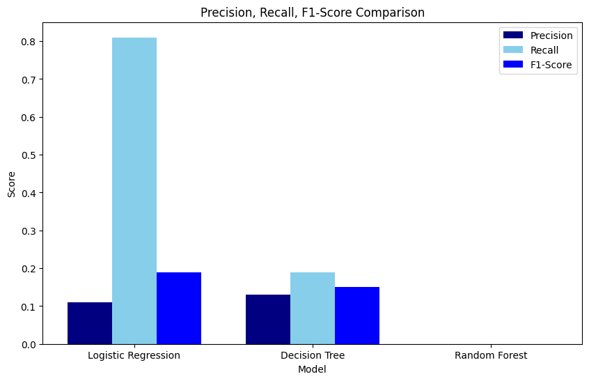

```python
import numpy as np

# Placeholder values for metrics from different models
metrics = {
    'Model': ['Logistic Regression', 'Decision Tree', 'Random Forest'],
    'Precision': [0.11, 0.13, 0.00],
    'Recall': [0.81, 0.19, 0.00],
    'F1-Score': [0.19, 0.15, 0.00]
}

# Convert to DataFrame for easier plotting (optional)
metrics_df = pd.DataFrame(metrics)

# Plot
bar_width = 0.25
index = np.arange(len(metrics_df['Model']))

plt.figure(figsize=(10, 6))
plt.bar(index, metrics_df['Precision'], bar_width, label='Precision', color='navy')
plt.bar(index + bar_width, metrics_df['Recall'], bar_width, label='Recall', color='skyblue')
plt.bar(index + 2 * bar_width, metrics_df['F1-Score'], bar_width, label='F1-Score', color='blue')

plt.xlabel('Model')
plt.ylabel('Score')
plt.title('Precision, Recall, F1-Score Comparison')
plt.xticks(index + bar_width, metrics_df['Model'])
plt.legend()
plt.show()
```

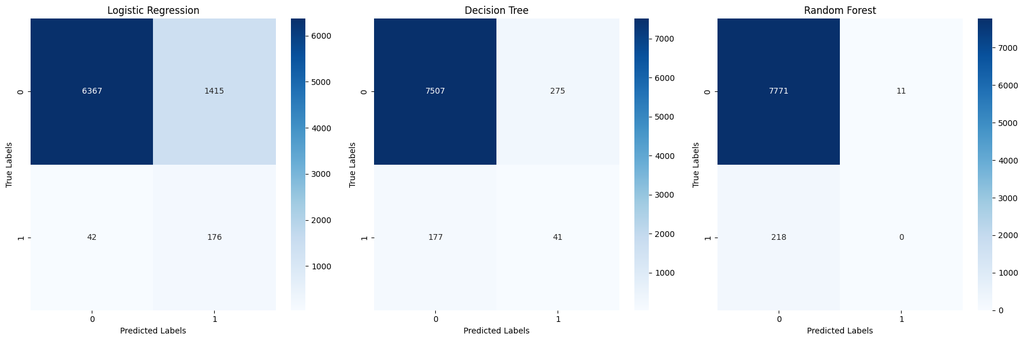

```python
import matplotlib.pyplot as plt
import seaborn as sns
from sklearn.metrics import confusion_matrix

# Define the true labels and predictions for demonstration purposes
y_true = [0] * 7782 + [1] * 218  # Actual classes (0 = Non-default, 1 = Default)

# Predicted classes for each model
y_pred_lr = [0] * 6367 + [1] * 1415 + [0] * 42 + [1] * 176  # Logistic Regression
y_pred_dt = [0] * 7507 + [1] * 275 + [0] * 177 + [1] * 41   # Decision Tree
y_pred_rf = [0] * 7771 + [1] * 11 + [0] * 218               # Random Forest

# Calculate confusion matrices
cm_lr = confusion_matrix(y_true, y_pred_lr)
cm_dt = confusion_matrix(y_true, y_pred_dt)
cm_rf = confusion_matrix(y_true, y_pred_rf)

# Plotting confusion matrices
fig, axes = plt.subplots(1, 3, figsize=(18, 6))
sns.heatmap(cm_lr, annot=True, fmt="d", cmap="Blues", ax=axes[0])
axes[0].set_title('Logistic Regression')
axes[0].set_xlabel('Predicted Labels')
axes[0].set_ylabel('True Labels')

sns.heatmap(cm_dt, annot=True, fmt="d", cmap="Blues", ax=axes[1])
axes[1].set_title('Decision Tree')
axes[1].set_xlabel('Predicted Labels')
axes[1].set_ylabel('True Labels')

sns.heatmap(cm_rf, annot=True, fmt="d", cmap="Blues", ax=axes[2])
axes[2].set_title('Random Forest')
axes[2].set_xlabel('Predicted Labels')
axes[2].set_ylabel('True Labels')

plt.tight_layout()
plt.show()
```

# Business KPIs describes specifically on the effects of the performance on the business.

**Better Risk Management:**

1. Impact: The model assists the bank to identify customers who are likely to develop a credit risk in repaying the loan granted to them. This makes it easier for the bank to make right decisions on who to give a loan to hence minimizing massively on the number of non performing loans.
2. KPI: Reduced loan losses and better overall portfolio performance.

**Targeted Marketing:**

1. Impact: Customer risk profile enables the bank to offer appropriate products and services to customers. This personalization makes the customers happier and loyal to the bank due to the efforts considered in serving them.
2. KPI: The overall benefits include higher satisfaction among clientele and better outcomes of marketing promotions.

**Cost Savings:**

1. Impact: This also helps avoid extensive manual analysis of risk assessment, which can be time-consuming and expensive.
2. KPI: Easier access to credit and less business expenses.

**Regulatory Compliance:**

1. Impact: On the other hand, risk estimates assist the bank in meeting the set standards and reducing fines hence enhancing the bank’s reputation.
2. KPI: Less compliance concerns, and improved overall regulatory status.

# Plan for Enhancement (If More Time Was Available)

**Refine the Model:**

1. Action: Continuously fine-tune and optimize the model by experimenting with various algorithms and techniques.
2. Goal: Achieve the most accurate predictions possible.

**Improve Features:**

1. Action: Develop new features and identify the most impactful ones to enhance the model’s performance.
2. Goal: Make the model more insightful and precise.

**Test and Combine Models:**

1. Action: Implement cross-validation to test the model's effectiveness across different data sets. Explore combining multiple models to boost performance.
2. Goal: Build a more dependable and robust predictive tool.

**Balance the Data:**

1. Action: Apply advanced methods to balance the data and address any imbalances. Consider acquiring additional data if necessary.
2. Goal: Ensure the model provides fair and accurate predictions for all customer groups.

**Enhance Model Transparency:**

1. Action: Create tools and visualizations that explain how the model arrives at its predictions.
2. Goal: Increase the model's transparency and foster greater trust among users.

**Deploy the Model:**

1. Action: Integrate the model into the bank’s systems for real-time use and ensure it operates smoothly in everyday processes.
2. Goal: Facilitate seamless and efficient application of the model in the bank's operations.

### Handle Missing Values:

## App_data

```python
missing_values_app_data = app_data.isnull().sum()
print(missing_values_app_data.to_string())
```

```
SK_ID_CURR                           0
TARGET                               0
NAME_CONTRACT_TYPE                   0
CODE_GENDER                          0
FLAG_OWN_CAR                         0
FLAG_OWN_REALTY                      0
CNT_CHILDREN                         0
AMT_INCOME_TOTAL                     0
AMT_CREDIT                           0
AMT_ANNUITY                         12
AMT_GOODS_PRICE                    278
NAME_TYPE_SUITE                   1292
NAME_INCOME_TYPE                     0
NAME_EDUCATION_TYPE                  0
NAME_FAMILY_STATUS                   0
NAME_HOUSING_TYPE                    0
REGION_POPULATION_RELATIVE           0
DAYS_BIRTH                           0
DAYS_EMPLOYED                        0
DAYS_REGISTRATION                    0
DAYS_ID_PUBLISH                      0
OWN_CAR_AGE                     202929
FLAG_MOBIL                           0
FLAG_EMP_PHONE                       0
FLAG_WORK_PHONE                      0
FLAG_CONT_MOBILE                     0
FLAG_PHONE                           0
FLAG_EMAIL                           0
OCCUPATION_TYPE                  96391
CNT_FAM_MEMBERS                      2
REGION_RATING_CLIENT                 0
REGION_RATING_CLIENT_W_CITY          0
WEEKDAY_APPR_PROCESS_START           0
HOUR_APPR_PROCESS_START              0
REG_REGION_NOT_LIVE_REGION           0
REG_REGION_NOT_WORK_REGION           0
LIVE_REGION_NOT_WORK_REGION          0
REG_CITY_NOT_LIVE_CITY               0
REG_CITY_NOT_WORK_CITY               0
LIVE_CITY_NOT_WORK_CITY              0
```

[output cut: 67 more lines]

```
FLAG_DOCUMENT_13                     0
FLAG_DOCUMENT_14                     0
FLAG_DOCUMENT_15                     0
FLAG_DOCUMENT_16                     0
FLAG_DOCUMENT_17                     0
FLAG_DOCUMENT_18                     0
FLAG_DOCUMENT_19                     0
FLAG_DOCUMENT_20                     0
FLAG_DOCUMENT_21                     0
AMT_REQ_CREDIT_BUREAU_HOUR       41519
AMT_REQ_CREDIT_BUREAU_DAY        41519
AMT_REQ_CREDIT_BUREAU_WEEK       41519
AMT_REQ_CREDIT_BUREAU_MON        41519
AMT_REQ_CREDIT_BUREAU_QRT        41519
AMT_REQ_CREDIT_BUREAU_YEAR       41519
```

```python
# Identify numeric columns
numeric_cols = app_data.select_dtypes(include=['number']).columns
print("Numeric columns:\n", numeric_cols)

# Identify non-numeric columns
non_numeric_cols = app_data.select_dtypes(exclude=['number']).columns
print("Non-numeric columns:\n", non_numeric_cols)
```

```
Numeric columns:
 Index(['SK_ID_CURR', 'TARGET', 'CNT_CHILDREN', 'AMT_INCOME_TOTAL',
       'AMT_CREDIT', 'AMT_ANNUITY', 'AMT_GOODS_PRICE',
       'REGION_POPULATION_RELATIVE', 'DAYS_BIRTH', 'DAYS_EMPLOYED',
       ...
       'FLAG_DOCUMENT_18', 'FLAG_DOCUMENT_19', 'FLAG_DOCUMENT_20',
       'FLAG_DOCUMENT_21', 'AMT_REQ_CREDIT_BUREAU_HOUR',
       'AMT_REQ_CREDIT_BUREAU_DAY', 'AMT_REQ_CREDIT_BUREAU_WEEK',
       'AMT_REQ_CREDIT_BUREAU_MON', 'AMT_REQ_CREDIT_BUREAU_QRT',
       'AMT_REQ_CREDIT_BUREAU_YEAR'],
      dtype='object', length=106)
Non-numeric columns:
 Index(['NAME_CONTRACT_TYPE', 'CODE_GENDER', 'FLAG_OWN_CAR', 'FLAG_OWN_REALTY',
       'NAME_TYPE_SUITE', 'NAME_INCOME_TYPE', 'NAME_EDUCATION_TYPE',
       'NAME_FAMILY_STATUS', 'NAME_HOUSING_TYPE', 'OCCUPATION_TYPE',
       'WEEKDAY_APPR_PROCESS_START', 'ORGANIZATION_TYPE', 'FONDKAPREMONT_MODE',
       'HOUSETYPE_MODE', 'WALLSMATERIAL_MODE', 'EMERGENCYSTATE_MODE'],
      dtype='object')
```

Impute Missing Values for Numeric Columns:

```python
# Impute missing values for numeric columns with the mean
app_data[numeric_cols] = app_data[numeric_cols].fillna(app_data[numeric_cols].mean())
```

```python
app_data[numeric_cols].head()
```

|  | SK_ID_CURR | TARGET | CNT_CHILDREN | AMT_INCOME_TOTAL | AMT_CREDIT | AMT_ANNUITY | AMT_GOODS_PRICE | REGION_POPULATION_RELATIVE | DAYS_BIRTH | DAYS_EMPLOYED | ... | FLAG_DOCUMENT_18 | FLAG_DOCUMENT_19 | FLAG_DOCUMENT_20 | FLAG_DOCUMENT_21 | AMT_REQ_CREDIT_BUREAU_HOUR | AMT_REQ_CREDIT_BUREAU_DAY | AMT_REQ_CREDIT_BUREAU_WEEK | AMT_REQ_CREDIT_BUREAU_MON | AMT_REQ_CREDIT_BUREAU_QRT | AMT_REQ_CREDIT_BUREAU_YEAR |
| --- | --- | --- | --- | --- | --- | --- | --- | --- | --- | --- | --- | --- | --- | --- | --- | --- | --- | --- | --- | --- | --- |
| 0 | 100002 | 1 | 0 | 202500.0 | 406597.5 | 24700.5 | 351000.0 | 0.018801 | -9461 | -637 | ... | 0 | 0 | 0 | 0 | 0.000000 | 0.000 | 0.000000 | 0.000000 | 0.000000 | 1.000000 |
| 1 | 100003 | 0 | 0 | 270000.0 | 1293502.5 | 35698.5 | 1129500.0 | 0.003541 | -16765 | -1188 | ... | 0 | 0 | 0 | 0 | 0.000000 | 0.000 | 0.000000 | 0.000000 | 0.000000 | 0.000000 |
| 2 | 100004 | 0 | 0 | 67500.0 | 135000.0 | 6750.0 | 135000.0 | 0.010032 | -19046 | -225 | ... | 0 | 0 | 0 | 0 | 0.000000 | 0.000 | 0.000000 | 0.000000 | 0.000000 | 0.000000 |
| 3 | 100006 | 0 | 0 | 135000.0 | 312682.5 | 29686.5 | 297000.0 | 0.008019 | -19005 | -3039 | ... | 0 | 0 | 0 | 0 | 0.006402 | 0.007 | 0.034362 | 0.267395 | 0.265474 | 1.899974 |
| 4 | 100007 | 0 | 0 | 121500.0 | 513000.0 | 21865.5 | 513000.0 | 0.028663 | -19932 | -3038 | ... | 0 | 0 | 0 | 0 | 0.000000 | 0.000 | 0.000000 | 0.000000 | 0.000000 | 0.000000 |

5 rows × 106 columns

Note:Filling with the mean is appropriate as it replaces missing values with a measure of central tendency. This method assumes that the missing data is missing at random.

Impute Missing Values for Non Numeric Columns(Categorical):

```python
# Impute missing values for categorical columns with the mode
app_data[non_numeric_cols] = app_data[non_numeric_cols].fillna(app_data[non_numeric_cols].mode().iloc[0])
app_data[non_numeric_cols].head()
```

|  | NAME_CONTRACT_TYPE | CODE_GENDER | FLAG_OWN_CAR | FLAG_OWN_REALTY | NAME_TYPE_SUITE | NAME_INCOME_TYPE | NAME_EDUCATION_TYPE | NAME_FAMILY_STATUS | NAME_HOUSING_TYPE | OCCUPATION_TYPE | WEEKDAY_APPR_PROCESS_START | ORGANIZATION_TYPE | FONDKAPREMONT_MODE | HOUSETYPE_MODE | WALLSMATERIAL_MODE | EMERGENCYSTATE_MODE |
| --- | --- | --- | --- | --- | --- | --- | --- | --- | --- | --- | --- | --- | --- | --- | --- | --- |
| 0 | Cash loans | M | N | Y | Unaccompanied | Working | Secondary / secondary special | Single / not married | House / apartment | Laborers | WEDNESDAY | Business Entity Type 3 | reg oper account | block of flats | Stone, brick | No |
| 1 | Cash loans | F | N | N | Family | State servant | Higher education | Married | House / apartment | Core staff | MONDAY | School | reg oper account | block of flats | Block | No |
| 2 | Revolving loans | M | Y | Y | Unaccompanied | Working | Secondary / secondary special | Single / not married | House / apartment | Laborers | MONDAY | Government | reg oper account | block of flats | Panel | No |
| 3 | Cash loans | F | N | Y | Unaccompanied | Working | Secondary / secondary special | Civil marriage | House / apartment | Laborers | WEDNESDAY | Business Entity Type 3 | reg oper account | block of flats | Panel | No |
| 4 | Cash loans | M | N | Y | Unaccompanied | Working | Secondary / secondary special | Single / not married | House / apartment | Core staff | THURSDAY | Religion | reg oper account | block of flats | Panel | No |

Note:

1. Filling with the mode is used because it replaces missing values with the most frequently occurring category, which can be a good approximation for missing values in categorical data.
2. I used iloc because it allows in handling cases where there might be multiple modes in categorical data, ensuring that a single value is chosen for imputation.

CHECK:

```python
missing_values_app_data = app_data.isnull().sum()
print(missing_values_app_data.to_string())
```

```
SK_ID_CURR                      0
TARGET                          0
NAME_CONTRACT_TYPE              0
CODE_GENDER                     0
FLAG_OWN_CAR                    0
FLAG_OWN_REALTY                 0
CNT_CHILDREN                    0
AMT_INCOME_TOTAL                0
AMT_CREDIT                      0
AMT_ANNUITY                     0
AMT_GOODS_PRICE                 0
NAME_TYPE_SUITE                 0
NAME_INCOME_TYPE                0
NAME_EDUCATION_TYPE             0
NAME_FAMILY_STATUS              0
NAME_HOUSING_TYPE               0
REGION_POPULATION_RELATIVE      0
DAYS_BIRTH                      0
DAYS_EMPLOYED                   0
DAYS_REGISTRATION               0
DAYS_ID_PUBLISH                 0
OWN_CAR_AGE                     0
FLAG_MOBIL                      0
FLAG_EMP_PHONE                  0
FLAG_WORK_PHONE                 0
FLAG_CONT_MOBILE                0
FLAG_PHONE                      0
FLAG_EMAIL                      0
OCCUPATION_TYPE                 0
CNT_FAM_MEMBERS                 0
REGION_RATING_CLIENT            0
REGION_RATING_CLIENT_W_CITY     0
WEEKDAY_APPR_PROCESS_START      0
HOUR_APPR_PROCESS_START         0
REG_REGION_NOT_LIVE_REGION      0
REG_REGION_NOT_WORK_REGION      0
LIVE_REGION_NOT_WORK_REGION     0
REG_CITY_NOT_LIVE_CITY          0
REG_CITY_NOT_WORK_CITY          0
LIVE_CITY_NOT_WORK_CITY         0
```

[output cut: 67 more lines]

```
FLAG_DOCUMENT_13                0
FLAG_DOCUMENT_14                0
FLAG_DOCUMENT_15                0
FLAG_DOCUMENT_16                0
FLAG_DOCUMENT_17                0
FLAG_DOCUMENT_18                0
FLAG_DOCUMENT_19                0
FLAG_DOCUMENT_20                0
FLAG_DOCUMENT_21                0
AMT_REQ_CREDIT_BUREAU_HOUR      0
AMT_REQ_CREDIT_BUREAU_DAY       0
AMT_REQ_CREDIT_BUREAU_WEEK      0
AMT_REQ_CREDIT_BUREAU_MON       0
AMT_REQ_CREDIT_BUREAU_QRT       0
AMT_REQ_CREDIT_BUREAU_YEAR      0
```

# Feature Encoding:

Convert categorical features into numerical values using encoding techniques like one-hot encoding.

```python
app_data_encoded = pd.get_dummies(app_data, drop_first=True)
prev_app_data_encoded = pd.get_dummies(prev_app_data, drop_first=True)
```

```python
app_data.columns
```

```
Index(['SK_ID_CURR', 'TARGET', 'NAME_CONTRACT_TYPE', 'CODE_GENDER',
       'FLAG_OWN_CAR', 'FLAG_OWN_REALTY', 'CNT_CHILDREN', 'AMT_INCOME_TOTAL',
       'AMT_CREDIT', 'AMT_ANNUITY',
       ...
       'FLAG_DOCUMENT_18', 'FLAG_DOCUMENT_19', 'FLAG_DOCUMENT_20',
       'FLAG_DOCUMENT_21', 'AMT_REQ_CREDIT_BUREAU_HOUR',
       'AMT_REQ_CREDIT_BUREAU_DAY', 'AMT_REQ_CREDIT_BUREAU_WEEK',
       'AMT_REQ_CREDIT_BUREAU_MON', 'AMT_REQ_CREDIT_BUREAU_QRT',
       'AMT_REQ_CREDIT_BUREAU_YEAR'],
      dtype='object', length=122)
```

### Prev_app_data

**Checking missing values**

```python
missing_values_prev_app_data = prev_app_data.isnull().sum()
print(missing_values_prev_app_data.to_string())
```

```
SK_ID_PREV                           0
SK_ID_CURR                           0
NAME_CONTRACT_TYPE                   0
AMT_ANNUITY                     372235
AMT_APPLICATION                      0
AMT_CREDIT                           1
AMT_DOWN_PAYMENT                895844
AMT_GOODS_PRICE                 385515
WEEKDAY_APPR_PROCESS_START           0
HOUR_APPR_PROCESS_START              0
FLAG_LAST_APPL_PER_CONTRACT          0
NFLAG_LAST_APPL_IN_DAY               0
RATE_DOWN_PAYMENT               895844
RATE_INTEREST_PRIMARY          1664263
RATE_INTEREST_PRIVILEGED       1664263
NAME_CASH_LOAN_PURPOSE               0
NAME_CONTRACT_STATUS                 0
DAYS_DECISION                        0
NAME_PAYMENT_TYPE                    0
CODE_REJECT_REASON                   0
NAME_TYPE_SUITE                 820405
NAME_CLIENT_TYPE                     0
NAME_GOODS_CATEGORY                  0
NAME_PORTFOLIO                       0
NAME_PRODUCT_TYPE                    0
CHANNEL_TYPE                         0
SELLERPLACE_AREA                     0
NAME_SELLER_INDUSTRY                 0
CNT_PAYMENT                     372230
NAME_YIELD_GROUP                     0
PRODUCT_COMBINATION                346
DAYS_FIRST_DRAWING              673065
DAYS_FIRST_DUE                  673065
DAYS_LAST_DUE_1ST_VERSION       673065
DAYS_LAST_DUE                   673065
DAYS_TERMINATION                673065
NFLAG_INSURED_ON_APPROVAL       673065
```

```python
prev_app_data.info()
```

```
<class 'pandas.core.frame.DataFrame'>
RangeIndex: 1670214 entries, 0 to 1670213
Data columns (total 37 columns):
 #   Column                       Non-Null Count    Dtype
---  ------                       --------------    -----
 0   SK_ID_PREV                   1670214 non-null  int64
 1   SK_ID_CURR                   1670214 non-null  int64
 2   NAME_CONTRACT_TYPE           1670214 non-null  object
 3   AMT_ANNUITY                  1297979 non-null  float64
 4   AMT_APPLICATION              1670214 non-null  float64
 5   AMT_CREDIT                   1670213 non-null  float64
 6   AMT_DOWN_PAYMENT             774370 non-null   float64
 7   AMT_GOODS_PRICE              1284699 non-null  float64
 8   WEEKDAY_APPR_PROCESS_START   1670214 non-null  object
 9   HOUR_APPR_PROCESS_START      1670214 non-null  int64
```

[output cut: 29 more lines]

**Checking the missing perecentage for all columns:**

```python
missing_percentage = prev_app_data.isnull().mean() * 100
print(missing_percentage.sort_values(ascending=False))
```

```
RATE_INTEREST_PRIVILEGED       99.643698
RATE_INTEREST_PRIMARY          99.643698
AMT_DOWN_PAYMENT               53.636480
RATE_DOWN_PAYMENT              53.636480
NAME_TYPE_SUITE                49.119754
NFLAG_INSURED_ON_APPROVAL      40.298129
DAYS_TERMINATION               40.298129
DAYS_LAST_DUE                  40.298129
DAYS_LAST_DUE_1ST_VERSION      40.298129
DAYS_FIRST_DUE                 40.298129
DAYS_FIRST_DRAWING             40.298129
AMT_GOODS_PRICE                23.081773
AMT_ANNUITY                    22.286665
CNT_PAYMENT                    22.286366
PRODUCT_COMBINATION             0.020716
AMT_CREDIT                      0.000060
NAME_YIELD_GROUP                0.000000
NAME_PORTFOLIO                  0.000000
NAME_SELLER_INDUSTRY            0.000000
SELLERPLACE_AREA                0.000000
CHANNEL_TYPE                    0.000000
NAME_PRODUCT_TYPE               0.000000
SK_ID_PREV                      0.000000
NAME_GOODS_CATEGORY             0.000000
NAME_CLIENT_TYPE                0.000000
CODE_REJECT_REASON              0.000000
SK_ID_CURR                      0.000000
DAYS_DECISION                   0.000000
NAME_CONTRACT_STATUS            0.000000
NAME_CASH_LOAN_PURPOSE          0.000000
NFLAG_LAST_APPL_IN_DAY          0.000000
FLAG_LAST_APPL_PER_CONTRACT     0.000000
HOUR_APPR_PROCESS_START         0.000000
WEEKDAY_APPR_PROCESS_START      0.000000
AMT_APPLICATION                 0.000000
NAME_CONTRACT_TYPE              0.000000
NAME_PAYMENT_TYPE               0.000000
dtype: float64
```

```python
prev_app_data["RATE_INTEREST_PRIVILEGED"].head()
```

```
0    0.867336
1         NaN
2         NaN
3         NaN
4         NaN
Name: RATE_INTEREST_PRIVILEGED, dtype: float64
```

```python
prev_app_data.head()
```

|  | SK_ID_PREV | SK_ID_CURR | NAME_CONTRACT_TYPE | AMT_ANNUITY | AMT_APPLICATION | AMT_CREDIT | AMT_DOWN_PAYMENT | AMT_GOODS_PRICE | WEEKDAY_APPR_PROCESS_START | HOUR_APPR_PROCESS_START | ... | NAME_SELLER_INDUSTRY | CNT_PAYMENT | NAME_YIELD_GROUP | PRODUCT_COMBINATION | DAYS_FIRST_DRAWING | DAYS_FIRST_DUE | DAYS_LAST_DUE_1ST_VERSION | DAYS_LAST_DUE | DAYS_TERMINATION | NFLAG_INSURED_ON_APPROVAL |
| --- | --- | --- | --- | --- | --- | --- | --- | --- | --- | --- | --- | --- | --- | --- | --- | --- | --- | --- | --- | --- | --- |
| 0 | 2030495 | 271877 | Consumer loans | 1730.430 | 17145.0 | 17145.0 | 0.0 | 17145.0 | SATURDAY | 15 | ... | Connectivity | 12.0 | middle | POS mobile with interest | 365243.0 | -42.0 | 300.0 | -42.0 | -37.0 | 0.0 |
| 1 | 2802425 | 108129 | Cash loans | 25188.615 | 607500.0 | 679671.0 | NaN | 607500.0 | THURSDAY | 11 | ... | XNA | 36.0 | low_action | Cash X-Sell: low | 365243.0 | -134.0 | 916.0 | 365243.0 | 365243.0 | 1.0 |
| 2 | 2523466 | 122040 | Cash loans | 15060.735 | 112500.0 | 136444.5 | NaN | 112500.0 | TUESDAY | 11 | ... | XNA | 12.0 | high | Cash X-Sell: high | 365243.0 | -271.0 | 59.0 | 365243.0 | 365243.0 | 1.0 |
| 3 | 2819243 | 176158 | Cash loans | 47041.335 | 450000.0 | 470790.0 | NaN | 450000.0 | MONDAY | 7 | ... | XNA | 12.0 | middle | Cash X-Sell: middle | 365243.0 | -482.0 | -152.0 | -182.0 | -177.0 | 1.0 |
| 4 | 1784265 | 202054 | Cash loans | 31924.395 | 337500.0 | 404055.0 | NaN | 337500.0 | THURSDAY | 9 | ... | XNA | 24.0 | high | Cash Street: high | NaN | NaN | NaN | NaN | NaN | NaN |

5 rows × 37 columns

**Drop columns with more than 99% missing values**

```python
cols_to_drop = ['RATE_INTEREST_PRIVILEGED', 'RATE_INTEREST_PRIMARY']
prev_app_data.drop(columns=cols_to_drop, inplace=True)
```

```python
prev_app_data.head()
```

|  | SK_ID_PREV | SK_ID_CURR | NAME_CONTRACT_TYPE | AMT_ANNUITY | AMT_APPLICATION | AMT_CREDIT | AMT_DOWN_PAYMENT | AMT_GOODS_PRICE | WEEKDAY_APPR_PROCESS_START | HOUR_APPR_PROCESS_START | ... | NAME_SELLER_INDUSTRY | CNT_PAYMENT | NAME_YIELD_GROUP | PRODUCT_COMBINATION | DAYS_FIRST_DRAWING | DAYS_FIRST_DUE | DAYS_LAST_DUE_1ST_VERSION | DAYS_LAST_DUE | DAYS_TERMINATION | NFLAG_INSURED_ON_APPROVAL |
| --- | --- | --- | --- | --- | --- | --- | --- | --- | --- | --- | --- | --- | --- | --- | --- | --- | --- | --- | --- | --- | --- |
| 0 | 2030495 | 271877 | Consumer loans | 1730.430 | 17145.0 | 17145.0 | 0.0 | 17145.0 | SATURDAY | 15 | ... | Connectivity | 12.0 | middle | POS mobile with interest | 365243.0 | -42.0 | 300.0 | -42.0 | -37.0 | 0.0 |
| 1 | 2802425 | 108129 | Cash loans | 25188.615 | 607500.0 | 679671.0 | NaN | 607500.0 | THURSDAY | 11 | ... | XNA | 36.0 | low_action | Cash X-Sell: low | 365243.0 | -134.0 | 916.0 | 365243.0 | 365243.0 | 1.0 |
| 2 | 2523466 | 122040 | Cash loans | 15060.735 | 112500.0 | 136444.5 | NaN | 112500.0 | TUESDAY | 11 | ... | XNA | 12.0 | high | Cash X-Sell: high | 365243.0 | -271.0 | 59.0 | 365243.0 | 365243.0 | 1.0 |
| 3 | 2819243 | 176158 | Cash loans | 47041.335 | 450000.0 | 470790.0 | NaN | 450000.0 | MONDAY | 7 | ... | XNA | 12.0 | middle | Cash X-Sell: middle | 365243.0 | -482.0 | -152.0 | -182.0 | -177.0 | 1.0 |
| 4 | 1784265 | 202054 | Cash loans | 31924.395 | 337500.0 | 404055.0 | NaN | 337500.0 | THURSDAY | 9 | ... | XNA | 24.0 | high | Cash Street: high | NaN | NaN | NaN | NaN | NaN | NaN |

5 rows × 35 columns

**Another way for droping columns**

```python
threshold = 60  # Set threshold to 60%
prev_app_data = prev_app_data.loc[:, missing_percentage < threshold]
```

```python
prev_app_data.head()
```

|  | SK_ID_PREV | SK_ID_CURR | NAME_CONTRACT_TYPE | AMT_ANNUITY | AMT_APPLICATION | AMT_CREDIT | AMT_DOWN_PAYMENT | AMT_GOODS_PRICE | WEEKDAY_APPR_PROCESS_START | HOUR_APPR_PROCESS_START | ... | NAME_SELLER_INDUSTRY | CNT_PAYMENT | NAME_YIELD_GROUP | PRODUCT_COMBINATION | DAYS_FIRST_DRAWING | DAYS_FIRST_DUE | DAYS_LAST_DUE_1ST_VERSION | DAYS_LAST_DUE | DAYS_TERMINATION | NFLAG_INSURED_ON_APPROVAL |
| --- | --- | --- | --- | --- | --- | --- | --- | --- | --- | --- | --- | --- | --- | --- | --- | --- | --- | --- | --- | --- | --- |
| 0 | 2030495 | 271877 | Consumer loans | 1730.430 | 17145.0 | 17145.0 | 0.0 | 17145.0 | SATURDAY | 15 | ... | Connectivity | 12.0 | middle | POS mobile with interest | 365243.0 | -42.0 | 300.0 | -42.0 | -37.0 | 0.0 |
| 1 | 2802425 | 108129 | Cash loans | 25188.615 | 607500.0 | 679671.0 | NaN | 607500.0 | THURSDAY | 11 | ... | XNA | 36.0 | low_action | Cash X-Sell: low | 365243.0 | -134.0 | 916.0 | 365243.0 | 365243.0 | 1.0 |
| 2 | 2523466 | 122040 | Cash loans | 15060.735 | 112500.0 | 136444.5 | NaN | 112500.0 | TUESDAY | 11 | ... | XNA | 12.0 | high | Cash X-Sell: high | 365243.0 | -271.0 | 59.0 | 365243.0 | 365243.0 | 1.0 |
| 3 | 2819243 | 176158 | Cash loans | 47041.335 | 450000.0 | 470790.0 | NaN | 450000.0 | MONDAY | 7 | ... | XNA | 12.0 | middle | Cash X-Sell: middle | 365243.0 | -482.0 | -152.0 | -182.0 | -177.0 | 1.0 |
| 4 | 1784265 | 202054 | Cash loans | 31924.395 | 337500.0 | 404055.0 | NaN | 337500.0 | THURSDAY | 9 | ... | XNA | 24.0 | high | Cash Street: high | NaN | NaN | NaN | NaN | NaN | NaN |

5 rows × 35 columns

**Impute Missing Values in Numerical Columns**

```python
# Select numerical columns
numerical_cols = prev_app_data.select_dtypes(include=['int64', 'float64']).columns.tolist()
numerical_cols
```

```
['SK_ID_PREV',
 'SK_ID_CURR',
 'AMT_ANNUITY',
 'AMT_APPLICATION',
 'AMT_CREDIT',
 'AMT_DOWN_PAYMENT',
 'AMT_GOODS_PRICE',
 'HOUR_APPR_PROCESS_START',
 'NFLAG_LAST_APPL_IN_DAY',
 'RATE_DOWN_PAYMENT',
 'DAYS_DECISION',
 'SELLERPLACE_AREA',
 'CNT_PAYMENT',
 'DAYS_FIRST_DRAWING',
 'DAYS_FIRST_DUE',
 'DAYS_LAST_DUE_1ST_VERSION',
 'DAYS_LAST_DUE',
 'DAYS_TERMINATION',
 'NFLAG_INSURED_ON_APPROVAL']
```

Filling Numerical Data with Mean or Median

**Mean:** It is sensitive to outliers, which can skew the mean, potentially leading to less accurate imputations.

```python
# for col in prev_app_data.select_dtypes(include=['float64', 'int64']).columns:
#     prev_app_data[col].fillna(prev_app_data[col].mean(), inplace=True)
```

```python
# prev_app_data.select_dtypes(include=['int64', 'float64']).head()
```

[output not shown]

another way using median:

**Median:** It is more robust to outliers and skewed distributions, providing a more accurate reflection of the central tendency in these cases.

```python
for col in prev_app_data.select_dtypes(include=['float64', 'int64']).columns:
    prev_app_data[col].fillna(prev_app_data[col].median(), inplace=True)
```

```python
prev_app_data.select_dtypes(include=['int64', 'float64']).head()
```

|  | SK_ID_PREV | SK_ID_CURR | AMT_ANNUITY | AMT_APPLICATION | AMT_CREDIT | AMT_DOWN_PAYMENT | AMT_GOODS_PRICE | HOUR_APPR_PROCESS_START | NFLAG_LAST_APPL_IN_DAY | RATE_DOWN_PAYMENT | DAYS_DECISION | SELLERPLACE_AREA | CNT_PAYMENT | DAYS_FIRST_DRAWING | DAYS_FIRST_DUE | DAYS_LAST_DUE_1ST_VERSION | DAYS_LAST_DUE | DAYS_TERMINATION | NFLAG_INSURED_ON_APPROVAL |
| --- | --- | --- | --- | --- | --- | --- | --- | --- | --- | --- | --- | --- | --- | --- | --- | --- | --- | --- | --- |
| 0 | 2030495 | 271877 | 1730.430 | 17145.0 | 17145.0 | 0.0 | 17145.0 | 15 | 1 | 0.000000 | -73 | 35 | 12.0 | 365243.0 | -42.0 | 300.0 | -42.0 | -37.0 | 0.0 |
| 1 | 2802425 | 108129 | 25188.615 | 607500.0 | 679671.0 | 1638.0 | 607500.0 | 11 | 1 | 0.051605 | -164 | -1 | 36.0 | 365243.0 | -134.0 | 916.0 | 365243.0 | 365243.0 | 1.0 |
| 2 | 2523466 | 122040 | 15060.735 | 112500.0 | 136444.5 | 1638.0 | 112500.0 | 11 | 1 | 0.051605 | -301 | -1 | 12.0 | 365243.0 | -271.0 | 59.0 | 365243.0 | 365243.0 | 1.0 |
| 3 | 2819243 | 176158 | 47041.335 | 450000.0 | 470790.0 | 1638.0 | 450000.0 | 7 | 1 | 0.051605 | -512 | -1 | 12.0 | 365243.0 | -482.0 | -152.0 | -182.0 | -177.0 | 1.0 |
| 4 | 1784265 | 202054 | 31924.395 | 337500.0 | 404055.0 | 1638.0 | 337500.0 | 9 | 1 | 0.051605 | -781 | -1 | 24.0 | 365243.0 | -831.0 | -361.0 | -537.0 | -499.0 | 0.0 |

**Impute Missing Values in Categorical Columns**

```python
# Select categorical columns
categorical_cols = prev_app_data.select_dtypes(include=['object']).columns.tolist()
categorical_cols
```

```
['NAME_CONTRACT_TYPE',
 'WEEKDAY_APPR_PROCESS_START',
 'FLAG_LAST_APPL_PER_CONTRACT',
 'NAME_CASH_LOAN_PURPOSE',
 'NAME_CONTRACT_STATUS',
 'NAME_PAYMENT_TYPE',
 'CODE_REJECT_REASON',
 'NAME_TYPE_SUITE',
 'NAME_CLIENT_TYPE',
 'NAME_GOODS_CATEGORY',
 'NAME_PORTFOLIO',
 'NAME_PRODUCT_TYPE',
 'CHANNEL_TYPE',
 'NAME_SELLER_INDUSTRY',
 'NAME_YIELD_GROUP',
 'PRODUCT_COMBINATION']
```

Filling Categorical Data with Mode

```python
for col in prev_app_data.select_dtypes(include=['object']).columns:
    prev_app_data[col].fillna(prev_app_data[col].mode()[0], inplace=True)
```

```python
prev_app_data.select_dtypes(include=['object']).head()
```

|  | NAME_CONTRACT_TYPE | WEEKDAY_APPR_PROCESS_START | FLAG_LAST_APPL_PER_CONTRACT | NAME_CASH_LOAN_PURPOSE | NAME_CONTRACT_STATUS | NAME_PAYMENT_TYPE | CODE_REJECT_REASON | NAME_TYPE_SUITE | NAME_CLIENT_TYPE | NAME_GOODS_CATEGORY | NAME_PORTFOLIO | NAME_PRODUCT_TYPE | CHANNEL_TYPE | NAME_SELLER_INDUSTRY | NAME_YIELD_GROUP | PRODUCT_COMBINATION |
| --- | --- | --- | --- | --- | --- | --- | --- | --- | --- | --- | --- | --- | --- | --- | --- | --- |
| 0 | Consumer loans | SATURDAY | Y | XAP | Approved | Cash through the bank | XAP | Unaccompanied | Repeater | Mobile | POS | XNA | Country-wide | Connectivity | middle | POS mobile with interest |
| 1 | Cash loans | THURSDAY | Y | XNA | Approved | XNA | XAP | Unaccompanied | Repeater | XNA | Cash | x-sell | Contact center | XNA | low_action | Cash X-Sell: low |
| 2 | Cash loans | TUESDAY | Y | XNA | Approved | Cash through the bank | XAP | Spouse, partner | Repeater | XNA | Cash | x-sell | Credit and cash offices | XNA | high | Cash X-Sell: high |
| 3 | Cash loans | MONDAY | Y | XNA | Approved | Cash through the bank | XAP | Unaccompanied | Repeater | XNA | Cash | x-sell | Credit and cash offices | XNA | middle | Cash X-Sell: middle |
| 4 | Cash loans | THURSDAY | Y | Repairs | Refused | Cash through the bank | HC | Unaccompanied | Repeater | XNA | Cash | walk-in | Credit and cash offices | XNA | high | Cash Street: high |

**Check:**

```python
print(prev_app_data.isnull().sum())
```

```
SK_ID_PREV                     0
SK_ID_CURR                     0
NAME_CONTRACT_TYPE             0
AMT_ANNUITY                    0
AMT_APPLICATION                0
AMT_CREDIT                     0
AMT_DOWN_PAYMENT               0
AMT_GOODS_PRICE                0
WEEKDAY_APPR_PROCESS_START     0
HOUR_APPR_PROCESS_START        0
FLAG_LAST_APPL_PER_CONTRACT    0
NFLAG_LAST_APPL_IN_DAY         0
RATE_DOWN_PAYMENT              0
NAME_CASH_LOAN_PURPOSE         0
NAME_CONTRACT_STATUS           0
DAYS_DECISION                  0
NAME_PAYMENT_TYPE              0
CODE_REJECT_REASON             0
NAME_TYPE_SUITE                0
NAME_CLIENT_TYPE               0
NAME_GOODS_CATEGORY            0
NAME_PORTFOLIO                 0
NAME_PRODUCT_TYPE              0
CHANNEL_TYPE                   0
SELLERPLACE_AREA               0
NAME_SELLER_INDUSTRY           0
CNT_PAYMENT                    0
NAME_YIELD_GROUP               0
PRODUCT_COMBINATION            0
DAYS_FIRST_DRAWING             0
DAYS_FIRST_DUE                 0
DAYS_LAST_DUE_1ST_VERSION      0
DAYS_LAST_DUE                  0
DAYS_TERMINATION               0
NFLAG_INSURED_ON_APPROVAL      0
dtype: int64
```

# Feature Scaling:

Standardize or normalize numerical features if necessary.

```python
from sklearn.preprocessing import StandardScaler

scaler = StandardScaler()
numerical_features = ['AMT_INCOME_TOTAL', 'AMT_CREDIT', 'AMT_ANNUITY']
app_data[numerical_features] = scaler.fit_transform(app_data[numerical_features])
```

### Feature Engineering:

## App_data

```python
app_data['income_credit_interaction'] = app_data['AMT_INCOME_TOTAL'] * app_data['AMT_CREDIT']
app_data.head()
```

|  | SK_ID_CURR | TARGET | NAME_CONTRACT_TYPE | CODE_GENDER | FLAG_OWN_CAR | FLAG_OWN_REALTY | CNT_CHILDREN | AMT_INCOME_TOTAL | AMT_CREDIT | AMT_ANNUITY | ... | FLAG_DOCUMENT_19 | FLAG_DOCUMENT_20 | FLAG_DOCUMENT_21 | AMT_REQ_CREDIT_BUREAU_HOUR | AMT_REQ_CREDIT_BUREAU_DAY | AMT_REQ_CREDIT_BUREAU_WEEK | AMT_REQ_CREDIT_BUREAU_MON | AMT_REQ_CREDIT_BUREAU_QRT | AMT_REQ_CREDIT_BUREAU_YEAR | income_credit_interaction |
| --- | --- | --- | --- | --- | --- | --- | --- | --- | --- | --- | --- | --- | --- | --- | --- | --- | --- | --- | --- | --- | --- |
| 0 | 100002 | 1 | Cash loans | M | N | Y | 0 | 0.142129 | -0.478095 | -0.166149 | ... | 0 | 0 | 0 | 0.000000 | 0.000 | 0.000000 | 0.000000 | 0.000000 | 1.000000 | -0.067951 |
| 1 | 100003 | 0 | Cash loans | F | N | N | 0 | 0.426792 | 1.725450 | 0.592677 | ... | 0 | 0 | 0 | 0.000000 | 0.000 | 0.000000 | 0.000000 | 0.000000 | 0.000000 | 0.736408 |
| 2 | 100004 | 0 | Revolving loans | M | Y | Y | 0 | -0.427196 | -1.152888 | -1.404676 | ... | 0 | 0 | 0 | 0.000000 | 0.000 | 0.000000 | 0.000000 | 0.000000 | 0.000000 | 0.492509 |
| 3 | 100006 | 0 | Cash loans | F | N | Y | 0 | -0.142533 | -0.711430 | 0.177869 | ... | 0 | 0 | 0 | 0.006402 | 0.007 | 0.034362 | 0.267395 | 0.265474 | 1.899974 | 0.101403 |
| 4 | 100007 | 0 | Cash loans | M | N | Y | 0 | -0.199466 | -0.213734 | -0.361755 | ... | 0 | 0 | 0 | 0.000000 | 0.000 | 0.000000 | 0.000000 | 0.000000 | 0.000000 | 0.042633 |

5 rows × 123 columns

```python
from sklearn.preprocessing import PolynomialFeatures
import pandas as pd

# Initialize PolynomialFeatures with degree=2 and without bias column
poly = PolynomialFeatures(degree=2, include_bias=False)

# Specify the numeric features for polynomial transformation
numeric_features = ['AMT_INCOME_TOTAL', 'AMT_CREDIT']

# Transform the specified numeric features
poly_features = poly.fit_transform(app_data[numeric_features])

# Create a DataFrame for the polynomial features with appropriate column names
poly_features_df = pd.DataFrame(poly_features, columns=poly.get_feature_names_out(numeric_features))

# Concatenate the original dataset with the new polynomial features
app_data = pd.concat([app_data, poly_features_df], axis=1)
```

```python
app_data.head()
# These new features can help capture interactions and non-linear relationships that may improve the model’s performance.
```

|  | SK_ID_CURR | TARGET | NAME_CONTRACT_TYPE | CODE_GENDER | FLAG_OWN_CAR | FLAG_OWN_REALTY | CNT_CHILDREN | AMT_INCOME_TOTAL | AMT_CREDIT | AMT_ANNUITY | ... | AMT_REQ_CREDIT_BUREAU_WEEK | AMT_REQ_CREDIT_BUREAU_MON | AMT_REQ_CREDIT_BUREAU_QRT | AMT_REQ_CREDIT_BUREAU_YEAR | income_credit_interaction | AMT_INCOME_TOTAL | AMT_CREDIT | AMT_INCOME_TOTAL^2 | AMT_INCOME_TOTAL AMT_CREDIT | AMT_CREDIT^2 |
| --- | --- | --- | --- | --- | --- | --- | --- | --- | --- | --- | --- | --- | --- | --- | --- | --- | --- | --- | --- | --- | --- |
| 0 | 100002 | 1 | Cash loans | M | N | Y | 0 | 0.142129 | -0.478095 | -0.166149 | ... | 0.000000 | 0.000000 | 0.000000 | 1.000000 | -0.067951 | 0.142129 | -0.478095 | 0.020201 | -0.067951 | 0.228575 |
| 1 | 100003 | 0 | Cash loans | F | N | N | 0 | 0.426792 | 1.725450 | 0.592677 | ... | 0.000000 | 0.000000 | 0.000000 | 0.000000 | 0.736408 | 0.426792 | 1.725450 | 0.182151 | 0.736408 | 2.977177 |
| 2 | 100004 | 0 | Revolving loans | M | Y | Y | 0 | -0.427196 | -1.152888 | -1.404676 | ... | 0.000000 | 0.000000 | 0.000000 | 0.000000 | 0.492509 | -0.427196 | -1.152888 | 0.182497 | 0.492509 | 1.329151 |
| 3 | 100006 | 0 | Cash loans | F | N | Y | 0 | -0.142533 | -0.711430 | 0.177869 | ... | 0.034362 | 0.267395 | 0.265474 | 1.899974 | 0.101403 | -0.142533 | -0.711430 | 0.020316 | 0.101403 | 0.506132 |
| 4 | 100007 | 0 | Cash loans | M | N | Y | 0 | -0.199466 | -0.213734 | -0.361755 | ... | 0.000000 | 0.000000 | 0.000000 | 0.000000 | 0.042633 | -0.199466 | -0.213734 | 0.039787 | 0.042633 | 0.045682 |

5 rows × 128 columns

```python
app_data['AMT_CREDIT'].isna().sum()
```

```
AMT_CREDIT    0
AMT_CREDIT    0
dtype: int64
```

```python
app_data['AMT_CREDIT'].shape
```

```
(307511, 2)
```

```python
print(app_data.columns)
```

```
Index(['SK_ID_CURR', 'TARGET', 'NAME_CONTRACT_TYPE', 'CODE_GENDER',
       'FLAG_OWN_CAR', 'FLAG_OWN_REALTY', 'CNT_CHILDREN', 'AMT_INCOME_TOTAL',
       'AMT_CREDIT', 'AMT_ANNUITY',
       ...
       'AMT_REQ_CREDIT_BUREAU_WEEK', 'AMT_REQ_CREDIT_BUREAU_MON',
       'AMT_REQ_CREDIT_BUREAU_QRT', 'AMT_REQ_CREDIT_BUREAU_YEAR',
       'income_credit_interaction', 'AMT_INCOME_TOTAL', 'AMT_CREDIT',
       'AMT_INCOME_TOTAL^2', 'AMT_INCOME_TOTAL AMT_CREDIT', 'AMT_CREDIT^2'],
      dtype='object', length=128)
```

### **Drop Duplicates:**

```python
# Check for duplicate columns
print(app_data.columns[app_data.columns.duplicated()])
```

```
Index(['AMT_INCOME_TOTAL', 'AMT_CREDIT'], dtype='object')
```

```python
# Drop duplicate columns
app_data = app_data.loc[:, ~app_data.columns.duplicated()]
```

```python
app_data.head()
```

|  | SK_ID_CURR | TARGET | NAME_CONTRACT_TYPE | CODE_GENDER | FLAG_OWN_CAR | FLAG_OWN_REALTY | CNT_CHILDREN | AMT_INCOME_TOTAL | AMT_CREDIT | AMT_ANNUITY | ... | AMT_REQ_CREDIT_BUREAU_HOUR | AMT_REQ_CREDIT_BUREAU_DAY | AMT_REQ_CREDIT_BUREAU_WEEK | AMT_REQ_CREDIT_BUREAU_MON | AMT_REQ_CREDIT_BUREAU_QRT | AMT_REQ_CREDIT_BUREAU_YEAR | income_credit_interaction | AMT_INCOME_TOTAL^2 | AMT_INCOME_TOTAL AMT_CREDIT | AMT_CREDIT^2 |
| --- | --- | --- | --- | --- | --- | --- | --- | --- | --- | --- | --- | --- | --- | --- | --- | --- | --- | --- | --- | --- | --- |
| 0 | 100002 | 1 | Cash loans | M | N | Y | 0 | 0.142129 | -0.478095 | -0.166149 | ... | 0.000000 | 0.000 | 0.000000 | 0.000000 | 0.000000 | 1.000000 | -0.067951 | 0.020201 | -0.067951 | 0.228575 |
| 1 | 100003 | 0 | Cash loans | F | N | N | 0 | 0.426792 | 1.725450 | 0.592677 | ... | 0.000000 | 0.000 | 0.000000 | 0.000000 | 0.000000 | 0.000000 | 0.736408 | 0.182151 | 0.736408 | 2.977177 |
| 2 | 100004 | 0 | Revolving loans | M | Y | Y | 0 | -0.427196 | -1.152888 | -1.404676 | ... | 0.000000 | 0.000 | 0.000000 | 0.000000 | 0.000000 | 0.000000 | 0.492509 | 0.182497 | 0.492509 | 1.329151 |
| 3 | 100006 | 0 | Cash loans | F | N | Y | 0 | -0.142533 | -0.711430 | 0.177869 | ... | 0.006402 | 0.007 | 0.034362 | 0.267395 | 0.265474 | 1.899974 | 0.101403 | 0.020316 | 0.101403 | 0.506132 |
| 4 | 100007 | 0 | Cash loans | M | N | Y | 0 | -0.199466 | -0.213734 | -0.361755 | ... | 0.000000 | 0.000 | 0.000000 | 0.000000 | 0.000000 | 0.000000 | 0.042633 | 0.039787 | 0.042633 | 0.045682 |

5 rows × 126 columns

```python
print(app_data.columns)
```

```
Index(['SK_ID_CURR', 'TARGET', 'NAME_CONTRACT_TYPE', 'CODE_GENDER',
       'FLAG_OWN_CAR', 'FLAG_OWN_REALTY', 'CNT_CHILDREN', 'AMT_INCOME_TOTAL',
       'AMT_CREDIT', 'AMT_ANNUITY',
       ...
       'AMT_REQ_CREDIT_BUREAU_HOUR', 'AMT_REQ_CREDIT_BUREAU_DAY',
       'AMT_REQ_CREDIT_BUREAU_WEEK', 'AMT_REQ_CREDIT_BUREAU_MON',
       'AMT_REQ_CREDIT_BUREAU_QRT', 'AMT_REQ_CREDIT_BUREAU_YEAR',
       'income_credit_interaction', 'AMT_INCOME_TOTAL^2',
       'AMT_INCOME_TOTAL AMT_CREDIT', 'AMT_CREDIT^2'],
      dtype='object', length=126)
```

```python
bins = [0, 500000, 1000000, 1500000, 2000000]
labels = ['Low', 'Medium', 'High', 'Very High']
app_data['credit_bins'] = pd.cut(app_data['AMT_CREDIT'], bins=bins, labels=labels)
```

```python
app_data.head()
```

|  | SK_ID_CURR | TARGET | NAME_CONTRACT_TYPE | CODE_GENDER | FLAG_OWN_CAR | FLAG_OWN_REALTY | CNT_CHILDREN | AMT_INCOME_TOTAL | AMT_CREDIT | AMT_ANNUITY | ... | AMT_REQ_CREDIT_BUREAU_DAY | AMT_REQ_CREDIT_BUREAU_WEEK | AMT_REQ_CREDIT_BUREAU_MON | AMT_REQ_CREDIT_BUREAU_QRT | AMT_REQ_CREDIT_BUREAU_YEAR | income_credit_interaction | AMT_INCOME_TOTAL^2 | AMT_INCOME_TOTAL AMT_CREDIT | AMT_CREDIT^2 | credit_bins |
| --- | --- | --- | --- | --- | --- | --- | --- | --- | --- | --- | --- | --- | --- | --- | --- | --- | --- | --- | --- | --- | --- |
| 0 | 100002 | 1 | Cash loans | M | N | Y | 0 | 0.142129 | -0.478095 | -0.166149 | ... | 0.000 | 0.000000 | 0.000000 | 0.000000 | 1.000000 | -0.067951 | 0.020201 | -0.067951 | 0.228575 | NaN |
| 1 | 100003 | 0 | Cash loans | F | N | N | 0 | 0.426792 | 1.725450 | 0.592677 | ... | 0.000 | 0.000000 | 0.000000 | 0.000000 | 0.000000 | 0.736408 | 0.182151 | 0.736408 | 2.977177 | Low |
| 2 | 100004 | 0 | Revolving loans | M | Y | Y | 0 | -0.427196 | -1.152888 | -1.404676 | ... | 0.000 | 0.000000 | 0.000000 | 0.000000 | 0.000000 | 0.492509 | 0.182497 | 0.492509 | 1.329151 | NaN |
| 3 | 100006 | 0 | Cash loans | F | N | Y | 0 | -0.142533 | -0.711430 | 0.177869 | ... | 0.007 | 0.034362 | 0.267395 | 0.265474 | 1.899974 | 0.101403 | 0.020316 | 0.101403 | 0.506132 | NaN |
| 4 | 100007 | 0 | Cash loans | M | N | Y | 0 | -0.199466 | -0.213734 | -0.361755 | ... | 0.000 | 0.000000 | 0.000000 | 0.000000 | 0.000000 | 0.042633 | 0.039787 | 0.042633 | 0.045682 | NaN |

5 rows × 127 columns

```python
# Check the new feature
print(app_data[['AMT_CREDIT', 'credit_bins']].head())
```

```
   AMT_CREDIT credit_bins
0   -0.478095         NaN
1    1.725450         Low
2   -1.152888         NaN
3   -0.711430         NaN
4   -0.213734         NaN
```

```python
app_data['age_years'] = -app_data['DAYS_BIRTH'] / 365
```

```python
app_data.head()
```

|  | SK_ID_CURR | TARGET | NAME_CONTRACT_TYPE | CODE_GENDER | FLAG_OWN_CAR | FLAG_OWN_REALTY | CNT_CHILDREN | AMT_INCOME_TOTAL | AMT_CREDIT | AMT_ANNUITY | ... | AMT_REQ_CREDIT_BUREAU_WEEK | AMT_REQ_CREDIT_BUREAU_MON | AMT_REQ_CREDIT_BUREAU_QRT | AMT_REQ_CREDIT_BUREAU_YEAR | income_credit_interaction | AMT_INCOME_TOTAL^2 | AMT_INCOME_TOTAL AMT_CREDIT | AMT_CREDIT^2 | credit_bins | age_years |
| --- | --- | --- | --- | --- | --- | --- | --- | --- | --- | --- | --- | --- | --- | --- | --- | --- | --- | --- | --- | --- | --- |
| 0 | 100002 | 1 | Cash loans | M | N | Y | 0 | 0.142129 | -0.478095 | -0.166149 | ... | 0.000000 | 0.000000 | 0.000000 | 1.000000 | -0.067951 | 0.020201 | -0.067951 | 0.228575 | NaN | 25.920548 |
| 1 | 100003 | 0 | Cash loans | F | N | N | 0 | 0.426792 | 1.725450 | 0.592677 | ... | 0.000000 | 0.000000 | 0.000000 | 0.000000 | 0.736408 | 0.182151 | 0.736408 | 2.977177 | Low | 45.931507 |
| 2 | 100004 | 0 | Revolving loans | M | Y | Y | 0 | -0.427196 | -1.152888 | -1.404676 | ... | 0.000000 | 0.000000 | 0.000000 | 0.000000 | 0.492509 | 0.182497 | 0.492509 | 1.329151 | NaN | 52.180822 |
| 3 | 100006 | 0 | Cash loans | F | N | Y | 0 | -0.142533 | -0.711430 | 0.177869 | ... | 0.034362 | 0.267395 | 0.265474 | 1.899974 | 0.101403 | 0.020316 | 0.101403 | 0.506132 | NaN | 52.068493 |
| 4 | 100007 | 0 | Cash loans | M | N | Y | 0 | -0.199466 | -0.213734 | -0.361755 | ... | 0.000000 | 0.000000 | 0.000000 | 0.000000 | 0.042633 | 0.039787 | 0.042633 | 0.045682 | NaN | 54.608219 |

5 rows × 128 columns

```python
# Check the new feature
print(app_data[['DAYS_BIRTH', 'age_years']].head(20))
```

```
    DAYS_BIRTH  age_years
0        -9461  25.920548
1       -16765  45.931507
2       -19046  52.180822
3       -19005  52.068493
4       -19932  54.608219
5       -16941  46.413699
6       -13778  37.747945
7       -18850  51.643836
8       -20099  55.065753
9       -14469  39.641096
10      -10197  27.936986
11      -20417  55.936986
12      -13439  36.819178
13      -14086  38.591781
14      -14583  39.953425
15       -8728  23.912329
16      -12931  35.427397
17       -9776  26.783562
18      -17718  48.542466
19      -11348  31.090411
```

Note:The DAYS_BIRTH column is typically a negative value because it measures the number of days before the reference date when the person was born.

```python
app_data['age_years'] = app_data['age_years'].astype(int)
```

```python
print(app_data[['DAYS_BIRTH', 'age_years']].head(20))
```

```
    DAYS_BIRTH  age_years
0        -9461         25
1       -16765         45
2       -19046         52
3       -19005         52
4       -19932         54
5       -16941         46
6       -13778         37
7       -18850         51
8       -20099         55
9       -14469         39
10      -10197         27
11      -20417         55
12      -13439         36
13      -14086         38
14      -14583         39
15       -8728         23
16      -12931         35
17       -9776         26
18      -17718         48
19      -11348         31
```

### Label Encoding:

</br> This method converts each category into a unique integer.

```python
from sklearn.preprocessing import LabelEncoder

# Initialize the LabelEncoder
label_encoder = LabelEncoder()

# Apply LabelEncoder to a column
app_data['CODE_GENDER_encoded'] = label_encoder.fit_transform(app_data['CODE_GENDER'])

# Verify changes
print(app_data[['CODE_GENDER', 'CODE_GENDER_encoded']].head())
```

```
  CODE_GENDER  CODE_GENDER_encoded
0           M                    1
1           F                    0
2           M                    1
3           F                    0
4           M                    1
```

```python
app_data.head()
```

|  | SK_ID_CURR | TARGET | NAME_CONTRACT_TYPE | CODE_GENDER | FLAG_OWN_CAR | FLAG_OWN_REALTY | CNT_CHILDREN | AMT_INCOME_TOTAL | AMT_CREDIT | AMT_ANNUITY | ... | AMT_REQ_CREDIT_BUREAU_MON | AMT_REQ_CREDIT_BUREAU_QRT | AMT_REQ_CREDIT_BUREAU_YEAR | income_credit_interaction | AMT_INCOME_TOTAL^2 | AMT_INCOME_TOTAL AMT_CREDIT | AMT_CREDIT^2 | credit_bins | age_years | CODE_GENDER_encoded |
| --- | --- | --- | --- | --- | --- | --- | --- | --- | --- | --- | --- | --- | --- | --- | --- | --- | --- | --- | --- | --- | --- |
| 0 | 100002 | 1 | Cash loans | M | N | Y | 0 | 0.142129 | -0.478095 | -0.166149 | ... | 0.000000 | 0.000000 | 1.000000 | -0.067951 | 0.020201 | -0.067951 | 0.228575 | NaN | 25 | 1 |
| 1 | 100003 | 0 | Cash loans | F | N | N | 0 | 0.426792 | 1.725450 | 0.592677 | ... | 0.000000 | 0.000000 | 0.000000 | 0.736408 | 0.182151 | 0.736408 | 2.977177 | Low | 45 | 0 |
| 2 | 100004 | 0 | Revolving loans | M | Y | Y | 0 | -0.427196 | -1.152888 | -1.404676 | ... | 0.000000 | 0.000000 | 0.000000 | 0.492509 | 0.182497 | 0.492509 | 1.329151 | NaN | 52 | 1 |
| 3 | 100006 | 0 | Cash loans | F | N | Y | 0 | -0.142533 | -0.711430 | 0.177869 | ... | 0.267395 | 0.265474 | 1.899974 | 0.101403 | 0.020316 | 0.101403 | 0.506132 | NaN | 52 | 0 |
| 4 | 100007 | 0 | Cash loans | M | N | Y | 0 | -0.199466 | -0.213734 | -0.361755 | ... | 0.000000 | 0.000000 | 0.000000 | 0.042633 | 0.039787 | 0.042633 | 0.045682 | NaN | 54 | 1 |

5 rows × 129 columns

```python
missing_values_app_data = app_data.isnull().sum()
print(missing_values_app_data.to_string())
```

```
SK_ID_CURR                           0
TARGET                               0
NAME_CONTRACT_TYPE                   0
CODE_GENDER                          0
FLAG_OWN_CAR                         0
FLAG_OWN_REALTY                      0
CNT_CHILDREN                         0
AMT_INCOME_TOTAL                     0
AMT_CREDIT                           0
AMT_ANNUITY                          0
AMT_GOODS_PRICE                      0
NAME_TYPE_SUITE                      0
NAME_INCOME_TYPE                     0
NAME_EDUCATION_TYPE                  0
NAME_FAMILY_STATUS                   0
NAME_HOUSING_TYPE                    0
REGION_POPULATION_RELATIVE           0
DAYS_BIRTH                           0
DAYS_EMPLOYED                        0
DAYS_REGISTRATION                    0
DAYS_ID_PUBLISH                      0
OWN_CAR_AGE                          0
FLAG_MOBIL                           0
FLAG_EMP_PHONE                       0
FLAG_WORK_PHONE                      0
FLAG_CONT_MOBILE                     0
FLAG_PHONE                           0
FLAG_EMAIL                           0
OCCUPATION_TYPE                      0
CNT_FAM_MEMBERS                      0
REGION_RATING_CLIENT                 0
REGION_RATING_CLIENT_W_CITY          0
WEEKDAY_APPR_PROCESS_START           0
HOUR_APPR_PROCESS_START              0
REG_REGION_NOT_LIVE_REGION           0
REG_REGION_NOT_WORK_REGION           0
LIVE_REGION_NOT_WORK_REGION          0
REG_CITY_NOT_LIVE_CITY               0
REG_CITY_NOT_WORK_CITY               0
LIVE_CITY_NOT_WORK_CITY              0
```

[output cut: 74 more lines]

```
FLAG_DOCUMENT_20                     0
FLAG_DOCUMENT_21                     0
AMT_REQ_CREDIT_BUREAU_HOUR           0
AMT_REQ_CREDIT_BUREAU_DAY            0
AMT_REQ_CREDIT_BUREAU_WEEK           0
AMT_REQ_CREDIT_BUREAU_MON            0
AMT_REQ_CREDIT_BUREAU_QRT            0
AMT_REQ_CREDIT_BUREAU_YEAR           0
income_credit_interaction            0
AMT_INCOME_TOTAL^2                   0
AMT_INCOME_TOTAL AMT_CREDIT          0
AMT_CREDIT^2                         0
credit_bins                     183333
age_years                            0
CODE_GENDER_encoded                  0
```

```python
# Ensure 'Unknown' is a category in the column
app_data['credit_bins'] = app_data['credit_bins'].cat.add_categories('Unknown')

# Fill missing values with 'Unknown'
app_data['credit_bins'].fillna('Unknown', inplace=True)
```

```python
missing_values_app_data = app_data.isnull().sum()
print(missing_values_app_data.to_string())
```

```
SK_ID_CURR                      0
TARGET                          0
NAME_CONTRACT_TYPE              0
CODE_GENDER                     0
FLAG_OWN_CAR                    0
FLAG_OWN_REALTY                 0
CNT_CHILDREN                    0
AMT_INCOME_TOTAL                0
AMT_CREDIT                      0
AMT_ANNUITY                     0
AMT_GOODS_PRICE                 0
NAME_TYPE_SUITE                 0
NAME_INCOME_TYPE                0
NAME_EDUCATION_TYPE             0
NAME_FAMILY_STATUS              0
NAME_HOUSING_TYPE               0
REGION_POPULATION_RELATIVE      0
DAYS_BIRTH                      0
DAYS_EMPLOYED                   0
DAYS_REGISTRATION               0
DAYS_ID_PUBLISH                 0
OWN_CAR_AGE                     0
FLAG_MOBIL                      0
FLAG_EMP_PHONE                  0
FLAG_WORK_PHONE                 0
FLAG_CONT_MOBILE                0
FLAG_PHONE                      0
FLAG_EMAIL                      0
OCCUPATION_TYPE                 0
CNT_FAM_MEMBERS                 0
REGION_RATING_CLIENT            0
REGION_RATING_CLIENT_W_CITY     0
WEEKDAY_APPR_PROCESS_START      0
HOUR_APPR_PROCESS_START         0
REG_REGION_NOT_LIVE_REGION      0
REG_REGION_NOT_WORK_REGION      0
LIVE_REGION_NOT_WORK_REGION     0
REG_CITY_NOT_LIVE_CITY          0
REG_CITY_NOT_WORK_CITY          0
LIVE_CITY_NOT_WORK_CITY         0
```

[output cut: 74 more lines]

```
FLAG_DOCUMENT_20                0
FLAG_DOCUMENT_21                0
AMT_REQ_CREDIT_BUREAU_HOUR      0
AMT_REQ_CREDIT_BUREAU_DAY       0
AMT_REQ_CREDIT_BUREAU_WEEK      0
AMT_REQ_CREDIT_BUREAU_MON       0
AMT_REQ_CREDIT_BUREAU_QRT       0
AMT_REQ_CREDIT_BUREAU_YEAR      0
income_credit_interaction       0
AMT_INCOME_TOTAL^2              0
AMT_INCOME_TOTAL AMT_CREDIT     0
AMT_CREDIT^2                    0
credit_bins                     0
age_years                       0
CODE_GENDER_encoded             0
```

### Handle Outliers:

Using Z-Scores: Calculate the Z-scores for numeric features to identify outliers.

```python
print(app_data.columns)
```

```
Index(['SK_ID_CURR', 'TARGET', 'NAME_CONTRACT_TYPE', 'CODE_GENDER',
       'FLAG_OWN_CAR', 'FLAG_OWN_REALTY', 'CNT_CHILDREN', 'AMT_INCOME_TOTAL',
       'AMT_CREDIT', 'AMT_ANNUITY',
       ...
       'AMT_REQ_CREDIT_BUREAU_MON', 'AMT_REQ_CREDIT_BUREAU_QRT',
       'AMT_REQ_CREDIT_BUREAU_YEAR', 'income_credit_interaction',
       'AMT_INCOME_TOTAL^2', 'AMT_INCOME_TOTAL AMT_CREDIT', 'AMT_CREDIT^2',
       'credit_bins', 'age_years', 'CODE_GENDER_encoded'],
      dtype='object', length=129)
```

```python
# from scipy import stats
# import numpy as np

# # Updated list of numeric features (removed 'age_years')
# numeric_features = ['AMT_INCOME_TOTAL', 'AMT_CREDIT', 'AMT_ANNUITY',
#                      'AMT_REQ_CREDIT_BUREAU_HOUR', 'AMT_REQ_CREDIT_BUREAU_DAY',
#                      'AMT_REQ_CREDIT_BUREAU_WEEK', 'AMT_REQ_CREDIT_BUREAU_MON',
#                      'AMT_REQ_CREDIT_BUREAU_QRT', 'AMT_REQ_CREDIT_BUREAU_YEAR']

# # Verify if these features are in the DataFrame
# existing_features = [col for col in numeric_features if col in app_data.columns]

# # Calculate Z-scores if there are numeric features available
# if existing_features:
#     z_scores = np.abs(stats.zscore(app_data[existing_features]))

#     # Define a threshold
#     threshold = 3

#     # Identify outliers
#     outliers = (z_scores > threshold).any(axis=1)

#     # Count and show number of outliers
#     print(f'Number of outliers: {np.sum(outliers)}')
# else:
#     print("No valid numeric features found in the DataFrame.")
```

[output not shown]

```python
# # Remove rows with outliers
# app_data_clean = app_data[~outliers]
# app_data_clean
```

[output not shown]

280873 rows × 129 columns

```python
app_data.info()
```

```
<class 'pandas.core.frame.DataFrame'>
RangeIndex: 307511 entries, 0 to 307510
Columns: 129 entries, SK_ID_CURR to CODE_GENDER_encoded
dtypes: category(1), float64(69), int32(2), int64(41), object(16)
memory usage: 298.3+ MB
```

```python
app_data_clean.info()
```

```
<class 'pandas.core.frame.DataFrame'>
Index: 280873 entries, 0 to 307510
Columns: 129 entries, SK_ID_CURR to CODE_GENDER_encoded
dtypes: category(1), float64(69), int32(2), int64(41), object(16)
memory usage: 274.6+ MB
```

```python
type(app_data)
```

```
pandas.core.frame.DataFrame
```

```python
app_data = app_data_clean
```

```python
app_data.info()
```

```
<class 'pandas.core.frame.DataFrame'>
Index: 280873 entries, 0 to 307510
Columns: 129 entries, SK_ID_CURR to CODE_GENDER_encoded
dtypes: category(1), float64(69), int32(2), int64(41), object(16)
memory usage: 274.6+ MB
```

# Save as Pickle

```python
app_data.to_pickle('preprocessed_app_data.pkl')
```

```python
# Load Pickle:
# import pandas as pd

# app_data = pd.read_pickle('preprocessed_app_data.pkl')
```

## Prev_app_data

```python
prev_app_data.head()
```

|  | SK_ID_PREV | SK_ID_CURR | NAME_CONTRACT_TYPE | AMT_ANNUITY | AMT_APPLICATION | AMT_CREDIT | AMT_DOWN_PAYMENT | AMT_GOODS_PRICE | WEEKDAY_APPR_PROCESS_START | HOUR_APPR_PROCESS_START | ... | NAME_SELLER_INDUSTRY | CNT_PAYMENT | NAME_YIELD_GROUP | PRODUCT_COMBINATION | DAYS_FIRST_DRAWING | DAYS_FIRST_DUE | DAYS_LAST_DUE_1ST_VERSION | DAYS_LAST_DUE | DAYS_TERMINATION | NFLAG_INSURED_ON_APPROVAL |
| --- | --- | --- | --- | --- | --- | --- | --- | --- | --- | --- | --- | --- | --- | --- | --- | --- | --- | --- | --- | --- | --- |
| 0 | 2030495 | 271877 | Consumer loans | 1730.430 | 17145.0 | 17145.0 | 0.0 | 17145.0 | SATURDAY | 15 | ... | Connectivity | 12.0 | middle | POS mobile with interest | 365243.0 | -42.0 | 300.0 | -42.0 | -37.0 | 0.0 |
| 1 | 2802425 | 108129 | Cash loans | 25188.615 | 607500.0 | 679671.0 | 1638.0 | 607500.0 | THURSDAY | 11 | ... | XNA | 36.0 | low_action | Cash X-Sell: low | 365243.0 | -134.0 | 916.0 | 365243.0 | 365243.0 | 1.0 |
| 2 | 2523466 | 122040 | Cash loans | 15060.735 | 112500.0 | 136444.5 | 1638.0 | 112500.0 | TUESDAY | 11 | ... | XNA | 12.0 | high | Cash X-Sell: high | 365243.0 | -271.0 | 59.0 | 365243.0 | 365243.0 | 1.0 |
| 3 | 2819243 | 176158 | Cash loans | 47041.335 | 450000.0 | 470790.0 | 1638.0 | 450000.0 | MONDAY | 7 | ... | XNA | 12.0 | middle | Cash X-Sell: middle | 365243.0 | -482.0 | -152.0 | -182.0 | -177.0 | 1.0 |
| 4 | 1784265 | 202054 | Cash loans | 31924.395 | 337500.0 | 404055.0 | 1638.0 | 337500.0 | THURSDAY | 9 | ... | XNA | 24.0 | high | Cash Street: high | 365243.0 | -831.0 | -361.0 | -537.0 | -499.0 | 0.0 |

5 rows × 35 columns

### Interaction Features

Credit-to-Annuity Ratio:

```python
prev_app_data['CREDIT_TO_ANNUITY_RATIO'] = prev_app_data['AMT_CREDIT'] / (prev_app_data['AMT_ANNUITY'] + 1e-6)  # Adding a small constant to avoid division by zero
```

```python
prev_app_data.head()
```

|  | SK_ID_PREV | SK_ID_CURR | NAME_CONTRACT_TYPE | AMT_ANNUITY | AMT_APPLICATION | AMT_CREDIT | AMT_DOWN_PAYMENT | AMT_GOODS_PRICE | WEEKDAY_APPR_PROCESS_START | HOUR_APPR_PROCESS_START | ... | CNT_PAYMENT | NAME_YIELD_GROUP | PRODUCT_COMBINATION | DAYS_FIRST_DRAWING | DAYS_FIRST_DUE | DAYS_LAST_DUE_1ST_VERSION | DAYS_LAST_DUE | DAYS_TERMINATION | NFLAG_INSURED_ON_APPROVAL | CREDIT_TO_ANNUITY_RATIO |
| --- | --- | --- | --- | --- | --- | --- | --- | --- | --- | --- | --- | --- | --- | --- | --- | --- | --- | --- | --- | --- | --- |
| 0 | 2030495 | 271877 | Consumer loans | 1730.430 | 17145.0 | 17145.0 | 0.0 | 17145.0 | SATURDAY | 15 | ... | 12.0 | middle | POS mobile with interest | 365243.0 | -42.0 | 300.0 | -42.0 | -37.0 | 0.0 | 9.907942 |
| 1 | 2802425 | 108129 | Cash loans | 25188.615 | 607500.0 | 679671.0 | 1638.0 | 607500.0 | THURSDAY | 11 | ... | 36.0 | low_action | Cash X-Sell: low | 365243.0 | -134.0 | 916.0 | 365243.0 | 365243.0 | 1.0 | 26.983262 |
| 2 | 2523466 | 122040 | Cash loans | 15060.735 | 112500.0 | 136444.5 | 1638.0 | 112500.0 | TUESDAY | 11 | ... | 12.0 | high | Cash X-Sell: high | 365243.0 | -271.0 | 59.0 | 365243.0 | 365243.0 | 1.0 | 9.059618 |
| 3 | 2819243 | 176158 | Cash loans | 47041.335 | 450000.0 | 470790.0 | 1638.0 | 450000.0 | MONDAY | 7 | ... | 12.0 | middle | Cash X-Sell: middle | 365243.0 | -482.0 | -152.0 | -182.0 | -177.0 | 1.0 | 10.008007 |
| 4 | 1784265 | 202054 | Cash loans | 31924.395 | 337500.0 | 404055.0 | 1638.0 | 337500.0 | THURSDAY | 9 | ... | 24.0 | high | Cash Street: high | 365243.0 | -831.0 | -361.0 | -537.0 | -499.0 | 0.0 | 12.656622 |

5 rows × 36 columns

Note:</br>

1. This ratio helps in understanding how much credit is provided relative to the loan repayment schedule.
2. A higher ratio may indicate a larger loan relative to the repayment capacity, which might impact default risk.

Down Payment Ratio:

```python
prev_app_data['DOWN_PAYMENT_RATIO'] = prev_app_data['AMT_DOWN_PAYMENT'] / (prev_app_data['AMT_CREDIT'] + 1e-6)
```

```python
prev_app_data.head(10)
```

|  | SK_ID_PREV | SK_ID_CURR | NAME_CONTRACT_TYPE | AMT_ANNUITY | AMT_APPLICATION | AMT_CREDIT | AMT_DOWN_PAYMENT | AMT_GOODS_PRICE | WEEKDAY_APPR_PROCESS_START | HOUR_APPR_PROCESS_START | ... | NAME_YIELD_GROUP | PRODUCT_COMBINATION | DAYS_FIRST_DRAWING | DAYS_FIRST_DUE | DAYS_LAST_DUE_1ST_VERSION | DAYS_LAST_DUE | DAYS_TERMINATION | NFLAG_INSURED_ON_APPROVAL | CREDIT_TO_ANNUITY_RATIO | DOWN_PAYMENT_RATIO |
| --- | --- | --- | --- | --- | --- | --- | --- | --- | --- | --- | --- | --- | --- | --- | --- | --- | --- | --- | --- | --- | --- |
| 0 | 2030495 | 271877 | Consumer loans | 1730.430 | 17145.0 | 17145.0 | 0.0 | 17145.0 | SATURDAY | 15 | ... | middle | POS mobile with interest | 365243.0 | -42.0 | 300.0 | -42.0 | -37.0 | 0.0 | 9.907942 | 0.000000e+00 |
| 1 | 2802425 | 108129 | Cash loans | 25188.615 | 607500.0 | 679671.0 | 1638.0 | 607500.0 | THURSDAY | 11 | ... | low_action | Cash X-Sell: low | 365243.0 | -134.0 | 916.0 | 365243.0 | 365243.0 | 1.0 | 26.983262 | 2.409990e-03 |
| 2 | 2523466 | 122040 | Cash loans | 15060.735 | 112500.0 | 136444.5 | 1638.0 | 112500.0 | TUESDAY | 11 | ... | high | Cash X-Sell: high | 365243.0 | -271.0 | 59.0 | 365243.0 | 365243.0 | 1.0 | 9.059618 | 1.200488e-02 |
| 3 | 2819243 | 176158 | Cash loans | 47041.335 | 450000.0 | 470790.0 | 1638.0 | 450000.0 | MONDAY | 7 | ... | middle | Cash X-Sell: middle | 365243.0 | -482.0 | -152.0 | -182.0 | -177.0 | 1.0 | 10.008007 | 3.479258e-03 |
| 4 | 1784265 | 202054 | Cash loans | 31924.395 | 337500.0 | 404055.0 | 1638.0 | 337500.0 | THURSDAY | 9 | ... | high | Cash Street: high | 365243.0 | -831.0 | -361.0 | -537.0 | -499.0 | 0.0 | 12.656622 | 4.053904e-03 |
| 5 | 1383531 | 199383 | Cash loans | 23703.930 | 315000.0 | 340573.5 | 1638.0 | 315000.0 | SATURDAY | 8 | ... | low_normal | Cash X-Sell: low | 365243.0 | -654.0 | -144.0 | -144.0 | -137.0 | 1.0 | 14.367807 | 4.809535e-03 |
| 6 | 2315218 | 175704 | Cash loans | 11250.000 | 0.0 | 0.0 | 1638.0 | 112320.0 | TUESDAY | 11 | ... | XNA | Cash | 365243.0 | -831.0 | -361.0 | -537.0 | -499.0 | 0.0 | 0.000000 | 1.638000e+09 |
| 7 | 1656711 | 296299 | Cash loans | 11250.000 | 0.0 | 0.0 | 1638.0 | 112320.0 | MONDAY | 7 | ... | XNA | Cash | 365243.0 | -831.0 | -361.0 | -537.0 | -499.0 | 0.0 | 0.000000 | 1.638000e+09 |
| 8 | 2367563 | 342292 | Cash loans | 11250.000 | 0.0 | 0.0 | 1638.0 | 112320.0 | MONDAY | 15 | ... | XNA | Cash | 365243.0 | -831.0 | -361.0 | -537.0 | -499.0 | 0.0 | 0.000000 | 1.638000e+09 |
| 9 | 2579447 | 334349 | Cash loans | 11250.000 | 0.0 | 0.0 | 1638.0 | 112320.0 | SATURDAY | 15 | ... | XNA | Cash | 365243.0 | -831.0 | -361.0 | -537.0 | -499.0 | 0.0 | 0.000000 | 1.638000e+09 |

10 rows × 37 columns

Note:</br>

1. The down payment ratio provides insight into the borrower’s equity stake in the loan.
2. A higher ratio might indicate a lower risk as the borrower is contributing more upfront.

### Temporal Features

represents the number of days since the application was made (DAYS_FIRST_DRAWING).

```python
prev_app_data['DAYS_SINCE_APPLICATION'] = prev_app_data['DAYS_FIRST_DRAWING'].fillna(0)
prev_app_data.head()
```

|  | SK_ID_PREV | SK_ID_CURR | NAME_CONTRACT_TYPE | AMT_ANNUITY | AMT_APPLICATION | AMT_CREDIT | AMT_DOWN_PAYMENT | AMT_GOODS_PRICE | WEEKDAY_APPR_PROCESS_START | HOUR_APPR_PROCESS_START | ... | PRODUCT_COMBINATION | DAYS_FIRST_DRAWING | DAYS_FIRST_DUE | DAYS_LAST_DUE_1ST_VERSION | DAYS_LAST_DUE | DAYS_TERMINATION | NFLAG_INSURED_ON_APPROVAL | CREDIT_TO_ANNUITY_RATIO | DOWN_PAYMENT_RATIO | DAYS_SINCE_APPLICATION |
| --- | --- | --- | --- | --- | --- | --- | --- | --- | --- | --- | --- | --- | --- | --- | --- | --- | --- | --- | --- | --- | --- |
| 0 | 2030495 | 271877 | Consumer loans | 1730.430 | 17145.0 | 17145.0 | 0.0 | 17145.0 | SATURDAY | 15 | ... | POS mobile with interest | 365243.0 | -42.0 | 300.0 | -42.0 | -37.0 | 0.0 | 9.907942 | 0.000000 | 365243.0 |
| 1 | 2802425 | 108129 | Cash loans | 25188.615 | 607500.0 | 679671.0 | 1638.0 | 607500.0 | THURSDAY | 11 | ... | Cash X-Sell: low | 365243.0 | -134.0 | 916.0 | 365243.0 | 365243.0 | 1.0 | 26.983262 | 0.002410 | 365243.0 |
| 2 | 2523466 | 122040 | Cash loans | 15060.735 | 112500.0 | 136444.5 | 1638.0 | 112500.0 | TUESDAY | 11 | ... | Cash X-Sell: high | 365243.0 | -271.0 | 59.0 | 365243.0 | 365243.0 | 1.0 | 9.059618 | 0.012005 | 365243.0 |
| 3 | 2819243 | 176158 | Cash loans | 47041.335 | 450000.0 | 470790.0 | 1638.0 | 450000.0 | MONDAY | 7 | ... | Cash X-Sell: middle | 365243.0 | -482.0 | -152.0 | -182.0 | -177.0 | 1.0 | 10.008007 | 0.003479 | 365243.0 |
| 4 | 1784265 | 202054 | Cash loans | 31924.395 | 337500.0 | 404055.0 | 1638.0 | 337500.0 | THURSDAY | 9 | ... | Cash Street: high | 365243.0 | -831.0 | -361.0 | -537.0 | -499.0 | 0.0 | 12.656622 | 0.004054 | 365243.0 |

5 rows × 38 columns

Note:

1. This helps in understanding the age of the loan application, which might influence approval decisions or default risk.

### Binning

This involves dividing the credit amount (AMT_CREDIT) into different bins or categories.

```python
bins = [0, 50000, 100000, 200000, 500000, np.inf]
labels = ['0-50k', '50k-100k', '100k-200k', '200k-500k', '500k+']
prev_app_data['CREDIT_AMOUNT_BIN'] = pd.cut(prev_app_data['AMT_CREDIT'], bins=bins, labels=labels)
```

```python
prev_app_data.head()
```

|  | SK_ID_PREV | SK_ID_CURR | NAME_CONTRACT_TYPE | AMT_ANNUITY | AMT_APPLICATION | AMT_CREDIT | AMT_DOWN_PAYMENT | AMT_GOODS_PRICE | WEEKDAY_APPR_PROCESS_START | HOUR_APPR_PROCESS_START | ... | DAYS_FIRST_DRAWING | DAYS_FIRST_DUE | DAYS_LAST_DUE_1ST_VERSION | DAYS_LAST_DUE | DAYS_TERMINATION | NFLAG_INSURED_ON_APPROVAL | CREDIT_TO_ANNUITY_RATIO | DOWN_PAYMENT_RATIO | DAYS_SINCE_APPLICATION | CREDIT_AMOUNT_BIN |
| --- | --- | --- | --- | --- | --- | --- | --- | --- | --- | --- | --- | --- | --- | --- | --- | --- | --- | --- | --- | --- | --- |
| 0 | 2030495 | 271877 | Consumer loans | 1730.430 | 17145.0 | 17145.0 | 0.0 | 17145.0 | SATURDAY | 15 | ... | 365243.0 | -42.0 | 300.0 | -42.0 | -37.0 | 0.0 | 9.907942 | 0.000000 | 365243.0 | 0-50k |
| 1 | 2802425 | 108129 | Cash loans | 25188.615 | 607500.0 | 679671.0 | 1638.0 | 607500.0 | THURSDAY | 11 | ... | 365243.0 | -134.0 | 916.0 | 365243.0 | 365243.0 | 1.0 | 26.983262 | 0.002410 | 365243.0 | 500k+ |
| 2 | 2523466 | 122040 | Cash loans | 15060.735 | 112500.0 | 136444.5 | 1638.0 | 112500.0 | TUESDAY | 11 | ... | 365243.0 | -271.0 | 59.0 | 365243.0 | 365243.0 | 1.0 | 9.059618 | 0.012005 | 365243.0 | 100k-200k |
| 3 | 2819243 | 176158 | Cash loans | 47041.335 | 450000.0 | 470790.0 | 1638.0 | 450000.0 | MONDAY | 7 | ... | 365243.0 | -482.0 | -152.0 | -182.0 | -177.0 | 1.0 | 10.008007 | 0.003479 | 365243.0 | 200k-500k |
| 4 | 1784265 | 202054 | Cash loans | 31924.395 | 337500.0 | 404055.0 | 1638.0 | 337500.0 | THURSDAY | 9 | ... | 365243.0 | -831.0 | -361.0 | -537.0 | -499.0 | 0.0 | 12.656622 | 0.004054 | 365243.0 | 200k-500k |

5 rows × 39 columns

Note:

1. Binning transforms continuous variables into categorical ones, which can simplify the model and help capture non-linear relationships.
2. It also makes the model more robust to outliers.

### Encode Categorical Variable:

One-Hot Encoding:Converts categorical variables into binary vectors

```python
prev_app_data = pd.get_dummies(prev_app_data, columns=['NAME_CONTRACT_TYPE', 'WEEKDAY_APPR_PROCESS_START'])
```

```python
prev_app_data.head(20)
```

|  | SK_ID_PREV | SK_ID_CURR | AMT_ANNUITY | AMT_APPLICATION | AMT_CREDIT | AMT_DOWN_PAYMENT | AMT_GOODS_PRICE | HOUR_APPR_PROCESS_START | FLAG_LAST_APPL_PER_CONTRACT | NFLAG_LAST_APPL_IN_DAY | ... | NAME_CONTRACT_TYPE_Consumer loans | NAME_CONTRACT_TYPE_Revolving loans | NAME_CONTRACT_TYPE_XNA | WEEKDAY_APPR_PROCESS_START_FRIDAY | WEEKDAY_APPR_PROCESS_START_MONDAY | WEEKDAY_APPR_PROCESS_START_SATURDAY | WEEKDAY_APPR_PROCESS_START_SUNDAY | WEEKDAY_APPR_PROCESS_START_THURSDAY | WEEKDAY_APPR_PROCESS_START_TUESDAY | WEEKDAY_APPR_PROCESS_START_WEDNESDAY |
| --- | --- | --- | --- | --- | --- | --- | --- | --- | --- | --- | --- | --- | --- | --- | --- | --- | --- | --- | --- | --- | --- |
| 0 | 2030495 | 271877 | 1730.430 | 17145.0 | 17145.0 | 0.0 | 17145.0 | 15 | Y | 1 | ... | True | False | False | False | False | True | False | False | False | False |
| 1 | 2802425 | 108129 | 25188.615 | 607500.0 | 679671.0 | 1638.0 | 607500.0 | 11 | Y | 1 | ... | False | False | False | False | False | False | False | True | False | False |
| 2 | 2523466 | 122040 | 15060.735 | 112500.0 | 136444.5 | 1638.0 | 112500.0 | 11 | Y | 1 | ... | False | False | False | False | False | False | False | False | True | False |
| 3 | 2819243 | 176158 | 47041.335 | 450000.0 | 470790.0 | 1638.0 | 450000.0 | 7 | Y | 1 | ... | False | False | False | False | True | False | False | False | False | False |
| 4 | 1784265 | 202054 | 31924.395 | 337500.0 | 404055.0 | 1638.0 | 337500.0 | 9 | Y | 1 | ... | False | False | False | False | False | False | False | True | False | False |
| 5 | 1383531 | 199383 | 23703.930 | 315000.0 | 340573.5 | 1638.0 | 315000.0 | 8 | Y | 1 | ... | False | False | False | False | False | True | False | False | False | False |
| 6 | 2315218 | 175704 | 11250.000 | 0.0 | 0.0 | 1638.0 | 112320.0 | 11 | Y | 1 | ... | False | False | False | False | False | False | False | False | True | False |
| 7 | 1656711 | 296299 | 11250.000 | 0.0 | 0.0 | 1638.0 | 112320.0 | 7 | Y | 1 | ... | False | False | False | False | True | False | False | False | False | False |
| 8 | 2367563 | 342292 | 11250.000 | 0.0 | 0.0 | 1638.0 | 112320.0 | 15 | Y | 1 | ... | False | False | False | False | True | False | False | False | False | False |
| 9 | 2579447 | 334349 | 11250.000 | 0.0 | 0.0 | 1638.0 | 112320.0 | 15 | Y | 1 | ... | False | False | False | False | False | True | False | False | False | False |
| 10 | 1715995 | 447712 | 11368.620 | 270000.0 | 335754.0 | 1638.0 | 270000.0 | 7 | Y | 1 | ... | False | False | False | True | False | False | False | False | False | False |
| 11 | 2257824 | 161140 | 13832.775 | 211500.0 | 246397.5 | 1638.0 | 211500.0 | 10 | Y | 1 | ... | False | False | False | True | False | False | False | False | False | False |
| 12 | 2330894 | 258628 | 12165.210 | 148500.0 | 174361.5 | 1638.0 | 148500.0 | 15 | Y | 1 | ... | False | False | False | False | False | False | False | False | True | False |
| 13 | 1397919 | 321676 | 7654.860 | 53779.5 | 57564.0 | 0.0 | 53779.5 | 15 | Y | 1 | ... | True | False | False | False | False | False | True | False | False | False |
| 14 | 2273188 | 270658 | 9644.220 | 26550.0 | 27252.0 | 0.0 | 26550.0 | 10 | Y | 1 | ... | True | False | False | False | False | True | False | False | False | False |
| 15 | 1232483 | 151612 | 21307.455 | 126490.5 | 119853.0 | 12649.5 | 126490.5 | 7 | Y | 1 | ... | True | False | False | False | False | False | False | False | True | False |
| 16 | 2163253 | 154602 | 4187.340 | 26955.0 | 27297.0 | 1350.0 | 26955.0 | 12 | Y | 1 | ... | True | False | False | False | False | True | False | False | False | False |
| 17 | 1285768 | 142748 | 9000.000 | 180000.0 | 180000.0 | 1638.0 | 180000.0 | 13 | Y | 1 | ... | False | True | False | True | False | False | False | False | False | False |
| 18 | 2393109 | 396305 | 10181.700 | 180000.0 | 180000.0 | 1638.0 | 180000.0 | 14 | Y | 1 | ... | False | False | False | False | False | False | False | True | False | False |
| 19 | 1173070 | 199178 | 4666.500 | 45000.0 | 49455.0 | 1638.0 | 45000.0 | 16 | Y | 1 | ... | False | False | False | False | False | True | False | False | False | False |

20 rows × 48 columns

Note:

1. Machine learning algorithms often require numerical input.
2. One-hot encoding transforms categorical variables into a format that can be easily used by algorithms.

```python
print(prev_app_data[['CREDIT_AMOUNT_BIN']].head())
```

```
  CREDIT_AMOUNT_BIN
0             0-50k
1             500k+
2         100k-200k
3         200k-500k
4         200k-500k
```

### Handling Outliers

```python
prev_app_data.head()
```

|  | SK_ID_PREV | SK_ID_CURR | AMT_ANNUITY | AMT_APPLICATION | AMT_CREDIT | AMT_DOWN_PAYMENT | AMT_GOODS_PRICE | HOUR_APPR_PROCESS_START | FLAG_LAST_APPL_PER_CONTRACT | NFLAG_LAST_APPL_IN_DAY | ... | NAME_CONTRACT_TYPE_Consumer loans | NAME_CONTRACT_TYPE_Revolving loans | NAME_CONTRACT_TYPE_XNA | WEEKDAY_APPR_PROCESS_START_FRIDAY | WEEKDAY_APPR_PROCESS_START_MONDAY | WEEKDAY_APPR_PROCESS_START_SATURDAY | WEEKDAY_APPR_PROCESS_START_SUNDAY | WEEKDAY_APPR_PROCESS_START_THURSDAY | WEEKDAY_APPR_PROCESS_START_TUESDAY | WEEKDAY_APPR_PROCESS_START_WEDNESDAY |
| --- | --- | --- | --- | --- | --- | --- | --- | --- | --- | --- | --- | --- | --- | --- | --- | --- | --- | --- | --- | --- | --- |
| 0 | 2030495 | 271877 | 1730.430 | 17145.0 | 17145.0 | 0.0 | 17145.0 | 15 | Y | 1 | ... | True | False | False | False | False | True | False | False | False | False |
| 1 | 2802425 | 108129 | 25188.615 | 607500.0 | 679671.0 | 1638.0 | 607500.0 | 11 | Y | 1 | ... | False | False | False | False | False | False | False | True | False | False |
| 2 | 2523466 | 122040 | 15060.735 | 112500.0 | 136444.5 | 1638.0 | 112500.0 | 11 | Y | 1 | ... | False | False | False | False | False | False | False | False | True | False |
| 3 | 2819243 | 176158 | 47041.335 | 450000.0 | 470790.0 | 1638.0 | 450000.0 | 7 | Y | 1 | ... | False | False | False | False | True | False | False | False | False | False |
| 4 | 1784265 | 202054 | 31924.395 | 337500.0 | 404055.0 | 1638.0 | 337500.0 | 9 | Y | 1 | ... | False | False | False | False | False | False | False | True | False | False |

5 rows × 48 columns

```python
from scipy import stats
import numpy as np
import pandas as pd

# List of numeric features to check for outliers
numeric_features = ['AMT_ANNUITY', 'AMT_APPLICATION', 'AMT_CREDIT',
                     'AMT_DOWN_PAYMENT', 'AMT_GOODS_PRICE']

# Verify if these features are in the DataFrame
existing_features = [col for col in numeric_features if col in prev_app_data.columns]

# Calculate Z-scores if there are numeric features available
if existing_features:
    # Drop NaN values for the selected features
    data_for_zscore = prev_app_data[existing_features].dropna()

    # Calculate Z-scores
    z_scores = np.abs(stats.zscore(data_for_zscore))

    # Define a threshold
    threshold = 3

    # Identify outliers
    outliers = (z_scores > threshold).any(axis=1)

    # Count the number of outliers
    num_outliers = np.sum(outliers)
    print(f'Number of outliers: {num_outliers}')

    # Optionally, display the rows with outliers
    outliers_df = prev_app_data.loc[outliers]
    print(outliers_df.head())  # Display the first few rows of outliers

else:
    print("No valid numeric features found in the DataFrame.")
```

```
Number of outliers: 76580
     SK_ID_PREV  SK_ID_CURR  AMT_ANNUITY  AMT_APPLICATION  AMT_CREDIT  \
23      1172937      302212    39475.305        1129500.0   1277104.5
47      1475738      235737    75897.630        2025000.0   2241513.0
79      2334831      430368    58021.695         877500.0   1031193.0
94      2408628      320444    55973.295        1035000.0   1110141.0
101     1196771      127624    49186.800        1170000.0   1170000.0

     AMT_DOWN_PAYMENT  AMT_GOODS_PRICE  HOUR_APPR_PROCESS_START  \
23             1638.0        1129500.0                        5
47             1638.0        2025000.0                       19
79             1638.0         877500.0                       16
94             1638.0        1035000.0                       16
101            1638.0        1170000.0                       17

```

[output cut: 43 more lines]

Identifies and removes extreme values that can skew results.

```python
Q1 = prev_app_data['AMT_CREDIT'].quantile(0.25)
Q3 = prev_app_data['AMT_CREDIT'].quantile(0.75)
IQR = Q3 - Q1
prev_app_data = prev_app_data[~((prev_app_data['AMT_CREDIT'] < (Q1 - 1.5 * IQR)) | (prev_app_data['AMT_CREDIT'] > (Q3 + 1.5 * IQR)))]
```

Note:

1. Outliers can disproportionately affect the model’s performance.
2. By detecting and removing them, you ensure that the model learns from the majority of the data and not just a few extreme cases

```python
# Check for remaining outliers
outliers_remaining = prev_app_data[(prev_app_data['AMT_CREDIT'] < (Q1 - 1.5 * IQR)) | (prev_app_data['AMT_CREDIT'] > (Q3 + 1.5 * IQR))]

print("Number of remaining outliers:", outliers_remaining.shape[0])
```

```
Number of remaining outliers: 0
```

### Remove Duplicates:

```python
prev_app_data.head()
```

|  | SK_ID_PREV | SK_ID_CURR | AMT_ANNUITY | AMT_APPLICATION | AMT_CREDIT | AMT_DOWN_PAYMENT | AMT_GOODS_PRICE | HOUR_APPR_PROCESS_START | FLAG_LAST_APPL_PER_CONTRACT | NFLAG_LAST_APPL_IN_DAY | ... | NAME_CONTRACT_TYPE_Consumer loans | NAME_CONTRACT_TYPE_Revolving loans | NAME_CONTRACT_TYPE_XNA | WEEKDAY_APPR_PROCESS_START_FRIDAY | WEEKDAY_APPR_PROCESS_START_MONDAY | WEEKDAY_APPR_PROCESS_START_SATURDAY | WEEKDAY_APPR_PROCESS_START_SUNDAY | WEEKDAY_APPR_PROCESS_START_THURSDAY | WEEKDAY_APPR_PROCESS_START_TUESDAY | WEEKDAY_APPR_PROCESS_START_WEDNESDAY |
| --- | --- | --- | --- | --- | --- | --- | --- | --- | --- | --- | --- | --- | --- | --- | --- | --- | --- | --- | --- | --- | --- |
| 0 | 2030495 | 271877 | 1730.430 | 17145.0 | 17145.0 | 0.0 | 17145.0 | 15 | Y | 1 | ... | True | False | False | False | False | True | False | False | False | False |
| 2 | 2523466 | 122040 | 15060.735 | 112500.0 | 136444.5 | 1638.0 | 112500.0 | 11 | Y | 1 | ... | False | False | False | False | False | False | False | False | True | False |
| 3 | 2819243 | 176158 | 47041.335 | 450000.0 | 470790.0 | 1638.0 | 450000.0 | 7 | Y | 1 | ... | False | False | False | False | True | False | False | False | False | False |
| 4 | 1784265 | 202054 | 31924.395 | 337500.0 | 404055.0 | 1638.0 | 337500.0 | 9 | Y | 1 | ... | False | False | False | False | False | False | False | True | False | False |
| 5 | 1383531 | 199383 | 23703.930 | 315000.0 | 340573.5 | 1638.0 | 315000.0 | 8 | Y | 1 | ... | False | False | False | False | False | True | False | False | False | False |

5 rows × 48 columns

```python
# Check for duplicates based on all columns
duplicates = prev_app_data.duplicated()
```

```python
num_duplicates = duplicates.sum()
print(f'Number of duplicate rows: {num_duplicates}')
```

```
Number of duplicate rows: 0
```

```python
missing_values_prev_app_data = prev_app_data.isnull().sum()
print(missing_values_prev_app_data.to_string())
```

```
SK_ID_PREV                                   0
SK_ID_CURR                                   0
AMT_ANNUITY                                  0
AMT_APPLICATION                              0
AMT_CREDIT                                   0
AMT_DOWN_PAYMENT                             0
AMT_GOODS_PRICE                              0
HOUR_APPR_PROCESS_START                      0
FLAG_LAST_APPL_PER_CONTRACT                  0
NFLAG_LAST_APPL_IN_DAY                       0
RATE_DOWN_PAYMENT                            0
NAME_CASH_LOAN_PURPOSE                       0
NAME_CONTRACT_STATUS                         0
DAYS_DECISION                                0
NAME_PAYMENT_TYPE                            0
CODE_REJECT_REASON                           0
NAME_TYPE_SUITE                              0
NAME_CLIENT_TYPE                             0
NAME_GOODS_CATEGORY                          0
NAME_PORTFOLIO                               0
NAME_PRODUCT_TYPE                            0
CHANNEL_TYPE                                 0
SELLERPLACE_AREA                             0
NAME_SELLER_INDUSTRY                         0
CNT_PAYMENT                                  0
NAME_YIELD_GROUP                             0
PRODUCT_COMBINATION                          0
DAYS_FIRST_DRAWING                           0
DAYS_FIRST_DUE                               0
DAYS_LAST_DUE_1ST_VERSION                    0
DAYS_LAST_DUE                                0
DAYS_TERMINATION                             0
NFLAG_INSURED_ON_APPROVAL                    0
CREDIT_TO_ANNUITY_RATIO                      0
DOWN_PAYMENT_RATIO                           0
DAYS_SINCE_APPLICATION                       0
CREDIT_AMOUNT_BIN                       336768
NAME_CONTRACT_TYPE_Cash loans                0
NAME_CONTRACT_TYPE_Consumer loans            0
NAME_CONTRACT_TYPE_Revolving loans           0
NAME_CONTRACT_TYPE_XNA                       0
WEEKDAY_APPR_PROCESS_START_FRIDAY            0
WEEKDAY_APPR_PROCESS_START_MONDAY            0
WEEKDAY_APPR_PROCESS_START_SATURDAY          0
WEEKDAY_APPR_PROCESS_START_SUNDAY            0
WEEKDAY_APPR_PROCESS_START_THURSDAY          0
WEEKDAY_APPR_PROCESS_START_TUESDAY           0
WEEKDAY_APPR_PROCESS_START_WEDNESDAY         0
```

```python
# Check missing values in CREDIT_AMOUNT_BIN
missing_values_count = prev_app_data['CREDIT_AMOUNT_BIN'].isnull().sum()
print(f"Number of missing values in CREDIT_AMOUNT_BIN: {missing_values_count}")
```

```
Number of missing values in CREDIT_AMOUNT_BIN: 336768
```

```python
# Fill missing values with the most frequent category
most_frequent_value = prev_app_data['CREDIT_AMOUNT_BIN'].mode()[0]
prev_app_data['CREDIT_AMOUNT_BIN'].fillna(most_frequent_value, inplace=True)
```

```python
missing_values_after = prev_app_data['CREDIT_AMOUNT_BIN'].isnull().sum()
print(f"Number of missing values in CREDIT_AMOUNT_BIN after imputation: {missing_values_after}")
```

```
Number of missing values in CREDIT_AMOUNT_BIN after imputation: 0
```

```python
print(prev_app_data[['CREDIT_AMOUNT_BIN']].head(20))
```

```
   CREDIT_AMOUNT_BIN
0              0-50k
2          100k-200k
3          200k-500k
4          200k-500k
5          200k-500k
6              0-50k
7              0-50k
8              0-50k
9              0-50k
10         200k-500k
11         200k-500k
12         100k-200k
13          50k-100k
14             0-50k
15         100k-200k
16             0-50k
17         100k-200k
18         100k-200k
19             0-50k
20         200k-500k
```

### Feature Scaling:

```python
from sklearn.preprocessing import StandardScaler

# Initialize the scaler
scaler = StandardScaler()

# Fit and transform numerical features
numerical_features = ['CREDIT_TO_ANNUITY_RATIO', 'DOWN_PAYMENT_RATIO', 'DAYS_SINCE_APPLICATION']
prev_app_data[numerical_features] = scaler.fit_transform(prev_app_data[numerical_features])
```

```python
print(prev_app_data.columns)
print(app_data.columns)
```

```
Index(['SK_ID_PREV', 'SK_ID_CURR', 'AMT_ANNUITY', 'AMT_APPLICATION',
       'AMT_CREDIT', 'AMT_DOWN_PAYMENT', 'AMT_GOODS_PRICE',
       'HOUR_APPR_PROCESS_START', 'FLAG_LAST_APPL_PER_CONTRACT',
       'NFLAG_LAST_APPL_IN_DAY', 'RATE_DOWN_PAYMENT', 'NAME_CASH_LOAN_PURPOSE',
       'NAME_CONTRACT_STATUS', 'DAYS_DECISION', 'NAME_PAYMENT_TYPE',
       'CODE_REJECT_REASON', 'NAME_TYPE_SUITE', 'NAME_CLIENT_TYPE',
       'NAME_GOODS_CATEGORY', 'NAME_PORTFOLIO', 'NAME_PRODUCT_TYPE',
       'CHANNEL_TYPE', 'SELLERPLACE_AREA', 'NAME_SELLER_INDUSTRY',
       'CNT_PAYMENT', 'NAME_YIELD_GROUP', 'PRODUCT_COMBINATION',
       'DAYS_FIRST_DRAWING', 'DAYS_FIRST_DUE', 'DAYS_LAST_DUE_1ST_VERSION',
       'DAYS_LAST_DUE', 'DAYS_TERMINATION', 'NFLAG_INSURED_ON_APPROVAL',
       'CREDIT_TO_ANNUITY_RATIO', 'DOWN_PAYMENT_RATIO',
       'DAYS_SINCE_APPLICATION', 'CREDIT_AMOUNT_BIN',
       'NAME_CONTRACT_TYPE_Cash loans', 'NAME_CONTRACT_TYPE_Consumer loans',
       'NAME_CONTRACT_TYPE_Revolving loans', 'NAME_CONTRACT_TYPE_XNA',
       'WEEKDAY_APPR_PROCESS_START_FRIDAY',
       'WEEKDAY_APPR_PROCESS_START_MONDAY',
       'WEEKDAY_APPR_PROCESS_START_SATURDAY',
       'WEEKDAY_APPR_PROCESS_START_SUNDAY',
       'WEEKDAY_APPR_PROCESS_START_THURSDAY',
       'WEEKDAY_APPR_PROCESS_START_TUESDAY',
       'WEEKDAY_APPR_PROCESS_START_WEDNESDAY'],
      dtype='object')
Index(['SK_ID_CURR', 'TARGET', 'NAME_CONTRACT_TYPE', 'CODE_GENDER',
       'FLAG_OWN_CAR', 'FLAG_OWN_REALTY', 'CNT_CHILDREN', 'AMT_INCOME_TOTAL',
       'AMT_CREDIT', 'AMT_ANNUITY',
       ...
       'AMT_REQ_CREDIT_BUREAU_MON', 'AMT_REQ_CREDIT_BUREAU_QRT',
       'AMT_REQ_CREDIT_BUREAU_YEAR', 'income_credit_interaction',
       'AMT_INCOME_TOTAL^2', 'AMT_INCOME_TOTAL AMT_CREDIT', 'AMT_CREDIT^2',
       'credit_bins', 'age_years', 'CODE_GENDER_encoded'],
      dtype='object', length=129)
```

# Save prev_app_data as Pickle

```python
prev_app_data.to_pickle('preprocessed_prev_app_data.pkl')
```

```python
# load:
# import pandas as pd

# prev_app_data = pd.read_pickle('preprocessed_prev_app_data.pkl')
```

# Data Merging:

```python
# Load the datasets
app_data = pd.read_csv('application_data.csv')
prev_app_data = pd.read_csv('previous_application.csv')
col_data = pd.read_csv('columns_description.csv')
```

```python
print("Application Dataset")
print(app_data.head())
print("\nPrevious Application Dataset")
print(prev_app_data.head())
print("\nColumns Description Dataset")
print(col_data.head())
```

```
Application Dataset
   SK_ID_CURR  TARGET NAME_CONTRACT_TYPE CODE_GENDER FLAG_OWN_CAR  \
0      100002       1         Cash loans           M            N
1      100003       0         Cash loans           F            N
2      100004       0    Revolving loans           M            Y
3      100006       0         Cash loans           F            N
4      100007       0         Cash loans           M            N

  FLAG_OWN_REALTY  CNT_CHILDREN  AMT_INCOME_TOTAL  AMT_CREDIT  AMT_ANNUITY  \
0               Y             0          202500.0    406597.5      24700.5
1               N             0          270000.0   1293502.5      35698.5
2               Y             0           67500.0    135000.0       6750.0
3               Y             0          135000.0    312682.5      29686.5
4               Y             0          121500.0    513000.0      21865.5

   ...  FLAG_DOCUMENT_18 FLAG_DOCUMENT_19 FLAG_DOCUMENT_20 FLAG_DOCUMENT_21  \
0  ...                 0                0                0                0
1  ...                 0                0                0                0
2  ...                 0                0                0                0
3  ...                 0                0                0                0
4  ...                 0                0                0                0

  AMT_REQ_CREDIT_BUREAU_HOUR AMT_REQ_CREDIT_BUREAU_DAY  \
0                        0.0                       0.0
1                        0.0                       0.0
2                        0.0                       0.0
3                        NaN                       NaN
4                        0.0                       0.0

   AMT_REQ_CREDIT_BUREAU_WEEK  AMT_REQ_CREDIT_BUREAU_MON  \
0                         0.0                        0.0
1                         0.0                        0.0
2                         0.0                        0.0
3                         NaN                        NaN
4                         0.0                        0.0

   AMT_REQ_CREDIT_BUREAU_QRT  AMT_REQ_CREDIT_BUREAU_YEAR
0                        0.0                         1.0
1                        0.0                         0.0
2                        0.0                         0.0
```

[output cut: 49 more lines]

```

Columns Description Dataset
   Unnamed: 0             Table                 Row  \
0           1  application_data          SK_ID_CURR
1           2  application_data              TARGET
2           5  application_data  NAME_CONTRACT_TYPE
3           6  application_data         CODE_GENDER
4           7  application_data        FLAG_OWN_CAR

                                         Description Special
0                           ID of loan in our sample     NaN
1  Target variable (1 - client with payment diffi...     NaN
2        Identification if loan is cash or revolving     NaN
3                               Gender of the client     NaN
4                      Flag if the client owns a car     NaN
```

```python
# Merge the datasets on SK_ID_CURR
merged_data = pd.merge(app_data, prev_app_data, on='SK_ID_CURR', how='left')

# Display the first few rows of the merged dataset
print(merged_data.head())
```

```
   SK_ID_CURR  TARGET NAME_CONTRACT_TYPE_x CODE_GENDER FLAG_OWN_CAR  \
0      100002       1           Cash loans           M            N
1      100003       0           Cash loans           F            N
2      100003       0           Cash loans           F            N
3      100003       0           Cash loans           F            N
4      100004       0      Revolving loans           M            Y

  FLAG_OWN_REALTY  CNT_CHILDREN  AMT_INCOME_TOTAL  AMT_CREDIT_x  \
0               Y             0          202500.0      406597.5
1               N             0          270000.0     1293502.5
2               N             0          270000.0     1293502.5
3               N             0          270000.0     1293502.5
4               Y             0           67500.0      135000.0

   AMT_ANNUITY_x  ...  NAME_SELLER_INDUSTRY CNT_PAYMENT NAME_YIELD_GROUP  \
```

[output cut: 28 more lines]

# EDA (Exploratory Data Analysis)

```python
# Check for missing values
missing_values = merged_data.isnull().sum()

# Check for duplicates
duplicates = merged_data.duplicated().sum()

# Display data types
data_types = merged_data.dtypes

print("Missing Values:\n", missing_values)
print("Duplicates: ", duplicates)
print("Data Types:\n", data_types)
```

```
Missing Values:
 SK_ID_CURR                        0
TARGET                            0
NAME_CONTRACT_TYPE_x              0
CODE_GENDER                       0
FLAG_OWN_CAR                      0
                              ...
DAYS_FIRST_DUE               577560
DAYS_LAST_DUE_1ST_VERSION    577560
DAYS_LAST_DUE                577560
DAYS_TERMINATION             577560
NFLAG_INSURED_ON_APPROVAL    577560
Length: 158, dtype: int64
Duplicates:  0
Data Types:
 SK_ID_CURR                     int64
TARGET                         int64
NAME_CONTRACT_TYPE_x          object
CODE_GENDER                   object
FLAG_OWN_CAR                  object
                              ...
DAYS_FIRST_DUE               float64
DAYS_LAST_DUE_1ST_VERSION    float64
DAYS_LAST_DUE                float64
DAYS_TERMINATION             float64
NFLAG_INSURED_ON_APPROVAL    float64
Length: 158, dtype: object
```

# Impute Missing Values

```python
missing_values = merged_data.isnull().sum()
print("Remaining Missing Values:\n", missing_values.to_string())
```

```
Remaining Missing Values:
 SK_ID_CURR                            0
TARGET                                0
NAME_CONTRACT_TYPE_x                  0
CODE_GENDER                           0
FLAG_OWN_CAR                          0
FLAG_OWN_REALTY                       0
CNT_CHILDREN                          0
AMT_INCOME_TOTAL                      0
AMT_CREDIT_x                          0
AMT_ANNUITY_x                        93
AMT_GOODS_PRICE_x                  1219
NAME_TYPE_SUITE_x                  4031
NAME_INCOME_TYPE                      0
NAME_EDUCATION_TYPE                   0
NAME_FAMILY_STATUS                    0
NAME_HOUSING_TYPE                     0
REGION_POPULATION_RELATIVE            0
DAYS_BIRTH                            0
DAYS_EMPLOYED                         0
DAYS_REGISTRATION                     0
DAYS_ID_PUBLISH                       0
OWN_CAR_AGE                      947574
FLAG_MOBIL                            0
FLAG_EMP_PHONE                        0
FLAG_WORK_PHONE                       0
FLAG_CONT_MOBILE                      0
FLAG_PHONE                            0
FLAG_EMAIL                            0
OCCUPATION_TYPE                  462731
CNT_FAM_MEMBERS                       2
REGION_RATING_CLIENT                  0
REGION_RATING_CLIENT_W_CITY           0
WEEKDAY_APPR_PROCESS_START_x          0
HOUR_APPR_PROCESS_START_x             0
REG_REGION_NOT_LIVE_REGION            0
REG_REGION_NOT_WORK_REGION            0
LIVE_REGION_NOT_WORK_REGION           0
REG_CITY_NOT_LIVE_CITY                0
REG_CITY_NOT_WORK_CITY                0
```

[output cut: 104 more lines]

[output not shown]

# Numeric Columns:

# Median Imputation:

```python
# Impute missing values for numeric columns with median
numeric_cols = merged_data.select_dtypes(include=[np.number]).columns
for col in numeric_cols:
    if merged_data[col].isnull().sum() > 0:
        merged_data[col].fillna(merged_data[col].median(), inplace=True)
```

# Mean or Constant Imputation:

For columns with fewer missing values or where median is not appropriate.

```python
merged_data['CNT_FAM_MEMBERS'].fillna(merged_data['CNT_FAM_MEMBERS'].mean(), inplace=True)
```

# Categorical Columns:

# Mode Imputation:

For categorical columns like NAME_TYPE_SUITE_x, OCCUPATION_TYPE

```python
# Impute missing values for categorical columns with mode
categorical_cols = merged_data.select_dtypes(include=[object]).columns
for col in categorical_cols:
    if merged_data[col].isnull().sum() > 0:
        merged_data[col].fillna(merged_data[col].mode()[0], inplace=True)
```

# Use of Constant Value:

For columns where 'Unknown' or other constant values are appropriate:

```python
merged_data['NAME_TYPE_SUITE_x'].fillna('Unknown', inplace=True)
merged_data['OCCUPATION_TYPE'].fillna('Unknown', inplace=True)
```

```python
missing_values = merged_data.isnull().sum()
print("Remaining Missing Values:\n", missing_values.to_string())
```

```
Remaining Missing Values:
 SK_ID_CURR                      0
TARGET                          0
NAME_CONTRACT_TYPE_x            0
CODE_GENDER                     0
FLAG_OWN_CAR                    0
FLAG_OWN_REALTY                 0
CNT_CHILDREN                    0
AMT_INCOME_TOTAL                0
AMT_CREDIT_x                    0
AMT_ANNUITY_x                   0
AMT_GOODS_PRICE_x               0
NAME_TYPE_SUITE_x               0
NAME_INCOME_TYPE                0
NAME_EDUCATION_TYPE             0
NAME_FAMILY_STATUS              0
NAME_HOUSING_TYPE               0
REGION_POPULATION_RELATIVE      0
DAYS_BIRTH                      0
DAYS_EMPLOYED                   0
DAYS_REGISTRATION               0
DAYS_ID_PUBLISH                 0
OWN_CAR_AGE                     0
FLAG_MOBIL                      0
FLAG_EMP_PHONE                  0
FLAG_WORK_PHONE                 0
FLAG_CONT_MOBILE                0
FLAG_PHONE                      0
FLAG_EMAIL                      0
OCCUPATION_TYPE                 0
CNT_FAM_MEMBERS                 0
REGION_RATING_CLIENT            0
REGION_RATING_CLIENT_W_CITY     0
WEEKDAY_APPR_PROCESS_START_x    0
HOUR_APPR_PROCESS_START_x       0
REG_REGION_NOT_LIVE_REGION      0
REG_REGION_NOT_WORK_REGION      0
LIVE_REGION_NOT_WORK_REGION     0
REG_CITY_NOT_LIVE_CITY          0
REG_CITY_NOT_WORK_CITY          0
```

[output cut: 104 more lines]

```
NAME_GOODS_CATEGORY             0
NAME_PORTFOLIO                  0
NAME_PRODUCT_TYPE               0
CHANNEL_TYPE                    0
SELLERPLACE_AREA                0
NAME_SELLER_INDUSTRY            0
CNT_PAYMENT                     0
NAME_YIELD_GROUP                0
PRODUCT_COMBINATION             0
DAYS_FIRST_DRAWING              0
DAYS_FIRST_DUE                  0
DAYS_LAST_DUE_1ST_VERSION       0
DAYS_LAST_DUE                   0
DAYS_TERMINATION                0
NFLAG_INSURED_ON_APPROVAL       0
```

# Check Data Types and Duplicates

```python
# Display data types
print("Data Types:\n", merged_data.dtypes)

# Check for duplicates
duplicates = merged_data.duplicated().sum()
print("Duplicates: ", duplicates)
```

```
Data Types:
 SK_ID_CURR                     int64
TARGET                         int64
NAME_CONTRACT_TYPE_x          object
CODE_GENDER                   object
FLAG_OWN_CAR                  object
                              ...
DAYS_FIRST_DUE               float64
DAYS_LAST_DUE_1ST_VERSION    float64
DAYS_LAST_DUE                float64
DAYS_TERMINATION             float64
NFLAG_INSURED_ON_APPROVAL    float64
Length: 158, dtype: object
Duplicates:  0
```

# Feature engineering and selection

```python
print(merged_data.columns)
```

```
Index(['SK_ID_CURR', 'TARGET', 'NAME_CONTRACT_TYPE_x', 'CODE_GENDER',
       'FLAG_OWN_CAR', 'FLAG_OWN_REALTY', 'CNT_CHILDREN', 'AMT_INCOME_TOTAL',
       'AMT_CREDIT_x', 'AMT_ANNUITY_x',
       ...
       'NAME_SELLER_INDUSTRY', 'CNT_PAYMENT', 'NAME_YIELD_GROUP',
       'PRODUCT_COMBINATION', 'DAYS_FIRST_DRAWING', 'DAYS_FIRST_DUE',
       'DAYS_LAST_DUE_1ST_VERSION', 'DAYS_LAST_DUE', 'DAYS_TERMINATION',
       'NFLAG_INSURED_ON_APPROVAL'],
      dtype='object', length=158)
```

```python
import pandas as pd
import numpy as np

# Example of creating interaction features
def create_interaction_features(df):
    # Create interaction features with the correct column names
    if 'AMT_INCOME_TOTAL' in df.columns and 'AMT_CREDIT_x' in df.columns:
        df['income_credit_interaction'] = df['AMT_INCOME_TOTAL'] * df['AMT_CREDIT_x']

    if 'DAYS_BIRTH' in df.columns and 'AMT_ANNUITY_x' in df.columns:
        df['age_annuity_interaction'] = df['DAYS_BIRTH'] * df['AMT_ANNUITY_x']

    # Add more interaction features as needed
    return df

# Call the function
merged_data = create_interaction_features(merged_data)
```

```python
print(merged_data[['income_credit_interaction', 'age_annuity_interaction']].head())
```

```
   income_credit_interaction  age_annuity_interaction
0               8.233599e+10             -233691430.5
1               3.492457e+11             -598485352.5
2               3.492457e+11             -598485352.5
3               3.492457e+11             -598485352.5
4               9.112500e+09             -128560500.0
```